# Project_1_607

Salma Elshahawy

9/16/2019

## Introduction

Chess is known as a noble game – “a game of kings“, and it is no coincidence, as it takes/develops similar skills.

In chess, just like in life, you can either aimlessly wonder around, hoping for a miracle, or set yourself a goal, build a plan and strive to accomplish it. The latter is no guarantee of success, but the former is a sure recipe for failure. **Chess teaches you to have a goal and overcome the obstacles on your way there**.

## Requirements

In this project, a text file with chess tournament results where the information has some structure given to me - in a text format. The requirements were to :

- Create an R Markdown file that generates a .CSV file that could for example be imported into a SQL database.
- The information should be like the following :

  | Player’s Name | Player’s State | Total Number of Points | Player’s Pre-Rating | Average Pre Chess Rating of Opponnents |
  | --- | --- | --- | --- | --- |
  | Gary Hua | ON | 6.0 | 1794 | 1605 |

## Questions

For this project, I was curious to get more insights into thses dataset. 1. Who has the most Pre-rating? 2. Which state has players with highest pre-rating? 3. What are the factors affects on winning tournaments?

## Work wireframe

I decided to put a plan how do I will handle, analyze the data given. This plan breaks down into steps, so I can easily follow these steps for more organized work.

## Steps to follow (Methodology):

1. Save the original tournamentinfo.txt file into my local machine then push it to my personal GitHub account.
2. Download necessary libraries.
3. Read the file as a dataframe using R Markdown.
4. Clean up the data from any special characters, empty strings,..etc.
5. Combine each two consecutive rows into one row - The table in the txt file are with **two tier headers and rows**
6. Seperate the columns from one column into multiples.
7. Get the opponents pre-rating year for each player
8. Calculate the average pre-rating for all opponents pre-rating for each player.
9. Explore the final dataframe and write the table to a csv file.
10. Do analysis to the defined model and get conclusion.

### Loading necessary liberaries

```r
library(RCurl)
library(htmlTable)
library(magrittr)
library(kableExtra)
library(dplyr)
library(stringr)
library(tidyverse)
```

```r
library(ggplot2)
library(Hmisc)
```

### Here I pushed the file into my GitHub account and store it into a variable and call read.delim() on it.

```r
url <- 'https://raw.githubusercontent.com/salma71/MSDS_2019/master/Fall2019/aquisition%26management_607/project_1/tournamentinfo.txt'

# reading the url as a dataframe
tourn <- read.delim(url, header = FALSE, stringsAsFactors = FALSE)
head(tourn) %>% kable() %>% kable_styling(bootstrap_options = c("striped", "hover", "condensed", "responsive")) %>% scroll_box(width="100%",height="300px")
```

| V1 |
| --- |
| —————————————————————————————– |
| Pair \| Player Name \|Total\|Round\|Round\|Round\|Round\|Round\|Round\|Round\| |
| Num \| USCF ID / Rtg (Pre->Post) \| Pts \| 1 \| 2 \| 3 \| 4 \| 5 \| 6 \| 7 \| |
| —————————————————————————————– |
| 1 \| GARY HUA \|6.0 \|W 39\|W 21\|W 18\|W 14\|W 7\|D 12\|D 4\| |
| ON \| 15445895 / R: 1794 ->1817 \|N:2 \|W \|B \|W \|B \|W \|B \|W \| |

```r
is.data.frame(tourn)
```

```
## [1] TRUE
```

1. As shown in the output, the table has many issues need to be handle first before analysing:
- The table has (-) needs to be removed
  - Has an empty rows
  - The data of each player is devided into two rows.

```r
# remove the ---- using str_remove_all with a regex pattern

tourn_2 <- data.frame(str_remove_all(tourn$V1,"(\\-+)"))
head(tourn_2) %>% kable() %>% kable_styling(bootstrap_options = c("striped", "hover", "condensed", "responsive")) %>% scroll_box(width="100%",height="300px")
```

| str_remove_all.tourn.V1……….. |
| --- |
| Pair \| Player Name \|Total\|Round\|Round\|Round\|Round\|Round\|Round\|Round\| |
| Num \| USCF ID / Rtg (Pre>Post) \| Pts \| 1 \| 2 \| 3 \| 4 \| 5 \| 6 \| 7 \| |
| 1 \| GARY HUA \|6.0 \|W 39\|W 21\|W 18\|W 14\|W 7\|D 12\|D 4\| |
| ON \| 15445895 / R: 1794 >1817 \|N:2 \|W \|B \|W \|B \|W \|B \|W \| |

```r
# now removing the extra empty rows from all the dataframe

tourn_2 <- data.frame(tourn_2[!apply(tourn_2 == "", 1, all),])
tourn_2 %>% kable() %>% kable_styling(bootstrap_options = c("striped", "hover", "condensed", "responsive")) %>% scroll_box(width="100%",height="300px")
```

| tourn_2..apply.tourn_2……..1..all…. |
| --- |
| Pair \| Player Name \|Total\|Round\|Round\|Round\|Round\|Round\|Round\|Round\| |
| Num \| USCF ID / Rtg (Pre>Post) \| Pts \| 1 \| 2 \| 3 \| 4 \| 5 \| 6 \| 7 \| |
| 1 \| GARY HUA \|6.0 \|W 39\|W 21\|W 18\|W 14\|W 7\|D 12\|D 4\| |
| ON \| 15445895 / R: 1794 >1817 \|N:2 \|W \|B \|W \|B \|W \|B \|W \| |
| 2 \| DAKSHESH DARURI \|6.0 \|W 63\|W 58\|L 4\|W 17\|W 16\|W 20\|W 7\| |
| MI \| 14598900 / R: 1553 >1663 \|N:2 \|B \|W \|B \|W \|B \|W \|B \| |
| 3 \| ADITYA BAJAJ \|6.0 \|L 8\|W 61\|W 25\|W 21\|W 11\|W 13\|W 12\| |
| MI \| 14959604 / R: 1384 >1640 \|N:2 \|W \|B \|W \|B \|W \|B \|W \| |
| 4 \| PATRICK H SCHILLING \|5.5 \|W 23\|D 28\|W 2\|W 26\|D 5\|W 19\|D 1\| |
| MI \| 12616049 / R: 1716 >1744 \|N:2 \|W \|B \|W \|B \|W \|B \|B \| |
| 5 \| HANSHI ZUO \|5.5 \|W 45\|W 37\|D 12\|D 13\|D 4\|W 14\|W 17\| |
| MI \| 14601533 / R: 1655 >1690 \|N:2 \|B \|W \|B \|W \|B \|W \|B \| |
| 6 \| HANSEN SONG \|5.0 \|W 34\|D 29\|L 11\|W 35\|D 10\|W 27\|W 21\| |
| OH \| 15055204 / R: 1686 >1687 \|N:3 \|W \|B \|W \|B \|B \|W \|B \| |
| 7 \| GARY DEE SWATHELL \|5.0 \|W 57\|W 46\|W 13\|W 11\|L 1\|W 9\|L 2\| |
| MI \| 11146376 / R: 1649 >1673 \|N:3 \|W \|B \|W \|B \|B \|W \|W \| |
| 8 \| EZEKIEL HOUGHTON \|5.0 \|W 3\|W 32\|L 14\|L 9\|W 47\|W 28\|W 19\| |
| MI \| 15142253 / R: 1641P17>1657P24 \|N:3 \|B \|W \|B \|W \|B \|W \|W \| |
| 9 \| STEFANO LEE \|5.0 \|W 25\|L 18\|W 59\|W 8\|W 26\|L 7\|W 20\| |
| ON \| 14954524 / R: 1411 >1564 \|N:2 \|W \|B \|W \|B \|W \|B \|B \| |
| 10 \| ANVIT RAO \|5.0 \|D 16\|L 19\|W 55\|W 31\|D 6\|W 25\|W 18\| |
| MI \| 14150362 / R: 1365 >1544 \|N:3 \|W \|W \|B \|B \|W \|B \|W \| |
| 11 \| CAMERON WILLIAM MC LEMAN \|4.5 \|D 38\|W 56\|W 6\|L 7\|L 3\|W 34\|W 26\| |
| MI \| 12581589 / R: 1712 >1696 \|N:3 \|B \|W \|B \|W \|B \|W \|B \| |
| 12 \| KENNETH J TACK \|4.5 \|W 42\|W 33\|D 5\|W 38\|H \|D 1\|L 3\| |
| MI \| 12681257 / R: 1663 >1670 \|N:3 \|W \|B \|W \|B \| \|W \|B \| |
| 13 \| TORRANCE HENRY JR \|4.5 \|W 36\|W 27\|L 7\|D 5\|W 33\|L 3\|W 32\| |
| MI \| 15082995 / R: 1666 >1662 \|N:3 \|B \|W \|B \|B \|W \|W \|B \| |
| 14 \| BRADLEY SHAW \|4.5 \|W 54\|W 44\|W 8\|L 1\|D 27\|L 5\|W 31\| |
| MI \| 10131499 / R: 1610 >1618 \|N:3 \|W \|B \|W \|W \|B \|B \|W \| |

[output cut: 100 more lines]

```r
# Need to define an empty new_dataframe
new_table <- data.frame(c())
# Combining two consecutive rows into one column
for (i in 1:dim(tourn_2)[1]){
  if (i %% 2 != 0) {
    Part1 <- rbind(new_table$Part1, as.character(tourn_2[i,1]))
    Part2 <- as.character(tourn_2[i+1,1])
    binded <- data.frame(paste0(Part1, Part2))
    names(binded) <- "Binded"
    new_table <- rbind(new_table, binded)
  }
}
head(new_table) %>% kable() %>% kable_styling(bootstrap_options = c("striped", "hover", "condensed", "responsive")) %>% scroll_box(width="100%",height="300px")
```

| Binded |
| --- |
| Pair \| Player Name \|Total\|Round\|Round\|Round\|Round\|Round\|Round\|Round\| Num \| USCF ID / Rtg (Pre>Post) \| Pts \| 1 \| 2 \| 3 \| 4 \| 5 \| 6 \| 7 \| |
| 1 \| GARY HUA \|6.0 \|W 39\|W 21\|W 18\|W 14\|W 7\|D 12\|D 4\| ON \| 15445895 / R: 1794 >1817 \|N:2 \|W \|B \|W \|B \|W \|B \|W \| |
| 2 \| DAKSHESH DARURI \|6.0 \|W 63\|W 58\|L 4\|W 17\|W 16\|W 20\|W 7\| MI \| 14598900 / R: 1553 >1663 \|N:2 \|B \|W \|B \|W \|B \|W \|B \| |
| 3 \| ADITYA BAJAJ \|6.0 \|L 8\|W 61\|W 25\|W 21\|W 11\|W 13\|W 12\| MI \| 14959604 / R: 1384 >1640 \|N:2 \|W \|B \|W \|B \|W \|B \|W \| |
| 4 \| PATRICK H SCHILLING \|5.5 \|W 23\|D 28\|W 2\|W 26\|D 5\|W 19\|D 1\| MI \| 12616049 / R: 1716 >1744 \|N:2 \|W \|B \|W \|B \|W \|B \|B \| |
| 5 \| HANSHI ZUO \|5.5 \|W 45\|W 37\|D 12\|D 13\|D 4\|W 14\|W 17\| MI \| 14601533 / R: 1655 >1690 \|N:2 \|B \|W \|B \|W \|B \|W \|B \| |

```r
# check that the new generated new_table is a dataframe
is.data.frame(new_table)
```

```
## [1] TRUE
```

##### Next step, we need to chop this long column into multiple columns, each column represents piece of data. For this purpose, I used built in method within tidyverse library called separate() which takes three arguments which are dataframe, the column that needs to be chopped, new columns names, and finally the separator where the split should be done. For this case, I wanted t split on the “|”.

#### For the columns names, I put it into a vector and stored it in a variable called “into”

```r
into <- c("Pair", "Player Name","Total","Round","Round.1","Round.2","Round.3","Round.4","Round.5","Round.6","State","USCF ID / Rtg (Pre>Post)","Pts","1","2", "3","4","5","6", "7")
splitted_df <- separate(new_table, Binded, into, sep = "\\|")
splitted_df %>% kable() %>% kable_styling(bootstrap_options = c("striped", "hover", "condensed", "responsive")) %>% scroll_box(width="100%",height="300px")
```

| Pair | Player Name | Total | Round | Round.1 | Round.2 | Round.3 | Round.4 | Round.5 | Round.6 | State | USCF ID / Rtg (Pre>Post) | Pts | 1 | 2 | 3 | 4 | 5 | 6 | 7 |
| --- | --- | --- | --- | --- | --- | --- | --- | --- | --- | --- | --- | --- | --- | --- | --- | --- | --- | --- | --- |
| Pair | Player Name | Total | Round | Round | Round | Round | Round | Round | Round | Num | USCF ID / Rtg (Pre>Post) | Pts | 1 | 2 | 3 | 4 | 5 | 6 | 7 |
| 1 | GARY HUA | 6.0 | W 39 | W 21 | W 18 | W 14 | W 7 | D 12 | D 4 | ON | 15445895 / R: 1794 >1817 | N:2 | W | B | W | B | W | B | W |
| 2 | DAKSHESH DARURI | 6.0 | W 63 | W 58 | L 4 | W 17 | W 16 | W 20 | W 7 | MI | 14598900 / R: 1553 >1663 | N:2 | B | W | B | W | B | W | B |
| 3 | ADITYA BAJAJ | 6.0 | L 8 | W 61 | W 25 | W 21 | W 11 | W 13 | W 12 | MI | 14959604 / R: 1384 >1640 | N:2 | W | B | W | B | W | B | W |
| 4 | PATRICK H SCHILLING | 5.5 | W 23 | D 28 | W 2 | W 26 | D 5 | W 19 | D 1 | MI | 12616049 / R: 1716 >1744 | N:2 | W | B | W | B | W | B | B |
| 5 | HANSHI ZUO | 5.5 | W 45 | W 37 | D 12 | D 13 | D 4 | W 14 | W 17 | MI | 14601533 / R: 1655 >1690 | N:2 | B | W | B | W | B | W | B |
| 6 | HANSEN SONG | 5.0 | W 34 | D 29 | L 11 | W 35 | D 10 | W 27 | W 21 | OH | 15055204 / R: 1686 >1687 | N:3 | W | B | W | B | B | W | B |
| 7 | GARY DEE SWATHELL | 5.0 | W 57 | W 46 | W 13 | W 11 | L 1 | W 9 | L 2 | MI | 11146376 / R: 1649 >1673 | N:3 | W | B | W | B | B | W | W |
| 8 | EZEKIEL HOUGHTON | 5.0 | W 3 | W 32 | L 14 | L 9 | W 47 | W 28 | W 19 | MI | 15142253 / R: 1641P17>1657P24 | N:3 | B | W | B | W | B | W | W |
| 9 | STEFANO LEE | 5.0 | W 25 | L 18 | W 59 | W 8 | W 26 | L 7 | W 20 | ON | 14954524 / R: 1411 >1564 | N:2 | W | B | W | B | W | B | B |
| 10 | ANVIT RAO | 5.0 | D 16 | L 19 | W 55 | W 31 | D 6 | W 25 | W 18 | MI | 14150362 / R: 1365 >1544 | N:3 | W | W | B | B | W | B | W |
| 11 | CAMERON WILLIAM MC LEMAN | 4.5 | D 38 | W 56 | W 6 | L 7 | L 3 | W 34 | W 26 | MI | 12581589 / R: 1712 >1696 | N:3 | B | W | B | W | B | W | B |
| 12 | KENNETH J TACK | 4.5 | W 42 | W 33 | D 5 | W 38 | H | D 1 | L 3 | MI | 12681257 / R: 1663 >1670 | N:3 | W | B | W | B |  | W | B |
| 13 | TORRANCE HENRY JR | 4.5 | W 36 | W 27 | L 7 | D 5 | W 33 | L 3 | W 32 | MI | 15082995 / R: 1666 >1662 | N:3 | B | W | B | B | W | W | B |
| 14 | BRADLEY SHAW | 4.5 | W 54 | W 44 | W 8 | L 1 | D 27 | L 5 | W 31 | MI | 10131499 / R: 1610 >1618 | N:3 | W | B | W | W | B | B | W |
| 15 | ZACHARY JAMES HOUGHTON | 4.5 | D 19 | L 16 | W 30 | L 22 | W 54 | W 33 | W 38 | MI | 15619130 / R: 1220P13>1416P20 | N:3 | B | B | W | W | B | B | W |
| 16 | MIKE NIKITIN | 4.0 | D 10 | W 15 | H | W 39 | L 2 | W 36 | U | MI | 10295068 / R: 1604 >1613 | N:3 | B | W |  | B | W | B |  |
| 17 | RONALD GRZEGORCZYK | 4.0 | W 48 | W 41 | L 26 | L 2 | W 23 | W 22 | L 5 | MI | 10297702 / R: 1629 >1610 | N:3 | W | B | W | B | W | B | W |
| 18 | DAVID SUNDEEN | 4.0 | W 47 | W 9 | L 1 | W 32 | L 19 | W 38 | L 10 | MI | 11342094 / R: 1600 >1600 | N:3 | B | W | B | W | B | W | B |
| 19 | DIPANKAR ROY | 4.0 | D 15 | W 10 | W 52 | D 28 | W 18 | L 4 | L 8 | MI | 14862333 / R: 1564 >1570 | N:3 | W | B | W | B | W | W | B |
| 20 | JASON ZHENG | 4.0 | L 40 | W 49 | W 23 | W 41 | W 28 | L 2 | L 9 | MI | 14529060 / R: 1595 >1569 | N:4 | W | B | W | B | W | B | W |
| 21 | DINH DANG BUI | 4.0 | W 43 | L 1 | W 47 | L 3 | W 40 | W 39 | L 6 | ON | 15495066 / R: 1563P22>1562 | N:3 | B | W | B | W | W | B | W |
| 22 | EUGENE L MCCLURE | 4.0 | W 64 | D 52 | L 28 | W 15 | H | L 17 | W 40 | MI | 12405534 / R: 1555 >1529 | N:4 | W | B | W | B |  | W | B |
| 23 | ALAN BUI | 4.0 | L 4 | W 43 | L 20 | W 58 | L 17 | W 37 | W 46 | ON | 15030142 / R: 1363 >1371 |  | B | W | B | W | B | W | B |
| 24 | MICHAEL R ALDRICH | 4.0 | L 28 | L 47 | W 43 | L 25 | W 60 | W 44 | W 39 | MI | 13469010 / R: 1229 >1300 | N:4 | B | W | B | B | W | W | B |
| 25 | LOREN SCHWIEBERT | 3.5 | L 9 | W 53 | L 3 | W 24 | D 34 | L 10 | W 47 | MI | 12486656 / R: 1745 >1681 | N:4 | B | W | B | W | B | W | B |
| 26 | MAX ZHU | 3.5 | W 49 | W 40 | W 17 | L 4 | L 9 | D 32 | L 11 | ON | 15131520 / R: 1579 >1564 | N:4 | B | W | B | W | B | W | W |
| 27 | GAURAV GIDWANI | 3.5 | W 51 | L 13 | W 46 | W 37 | D 14 | L 6 | U | MI | 14476567 / R: 1552 >1539 | N:4 | W | B | W | B | W | B |  |
| 28 | SOFIA ADINA STANESCUBELLU | 3.5 | W 24 | D 4 | W 22 | D 19 | L 20 | L 8 | D 36 | MI | 14882954 / R: 1507 >1513 | N:3 | W | W | B | W | B | B | W |
| 29 | CHIEDOZIE OKORIE | 3.5 | W 50 | D 6 | L 38 | L 34 | W 52 | W 48 | U | MI | 15323285 / R: 1602P6 >1508P12 | N:4 | B | W | B | W | W | B |  |
| 30 | GEORGE AVERY JONES | 3.5 | L 52 | D 64 | L 15 | W 55 | L 31 | W 61 | W 50 | ON | 12577178 / R: 1522 >1444 |  | W | B | B | W | W | B | B |
| 31 | RISHI SHETTY | 3.5 | L 58 | D 55 | W 64 | L 10 | W 30 | W 50 | L 14 | MI | 15131618 / R: 1494 >1444 |  | B | W | B | W | B | W | B |
| 32 | JOSHUA PHILIP MATHEWS | 3.5 | W 61 | L 8 | W 44 | L 18 | W 51 | D 26 | L 13 | ON | 14073750 / R: 1441 >1433 | N:4 | W | B | W | B | W | B | W |
| 33 | JADE GE | 3.5 | W 60 | L 12 | W 50 | D 36 | L 13 | L 15 | W 51 | MI | 14691842 / R: 1449 >1421 |  | B | W | B | W | B | W | B |
| 34 | MICHAEL JEFFERY THOMAS | 3.5 | L 6 | W 60 | L 37 | W 29 | D 25 | L 11 | W 52 | MI | 15051807 / R: 1399 >1400 |  | B | W | B | B | W | B | W |
| 35 | JOSHUA DAVID LEE | 3.5 | L 46 | L 38 | W 56 | L 6 | W 57 | D 52 | W 48 | MI | 14601397 / R: 1438 >1392 |  | W | W | B | W | B | B | W |
| 36 | SIDDHARTH JHA | 3.5 | L 13 | W 57 | W 51 | D 33 | H | L 16 | D 28 | MI | 14773163 / R: 1355 >1367 | N:4 | W | B | W | B |  | W | B |
| 37 | AMIYATOSH PWNANANDAM | 3.5 | B | L 5 | W 34 | L 27 | H | L 23 | W 61 | MI | 15489571 / R: 980P12>1077P17 |  |  | B | W | W |  | B | W |
| 38 | BRIAN LIU | 3.0 | D 11 | W 35 | W 29 | L 12 | H | L 18 | L 15 | MI | 15108523 / R: 1423 >1439 | N:4 | W | B | W | W |  | B | B |
| 39 | JOEL R HENDON | 3.0 | L 1 | W 54 | W 40 | L 16 | W 44 | L 21 | L 24 | MI | 12923035 / R: 1436P23>1413 | N:4 | B | W | B | W | B | W | W |
| 40 | FOREST ZHANG | 3.0 | W 20 | L 26 | L 39 | W 59 | L 21 | W 56 | L 22 | MI | 14892710 / R: 1348 >1346 |  | B | B | W | W | B | W | W |
| 41 | KYLE WILLIAM MURPHY | 3.0 | W 59 | L 17 | W 58 | L 20 | X | U | U | MI | 15761443 / R: 1403P5 >1341P9 |  | B | W | B | W |  |  |  |
| 42 | JARED GE | 3.0 | L 12 | L 50 | L 57 | D 60 | D 61 | W 64 | W 56 | MI | 14462326 / R: 1332 >1256 |  | B | W | B | B | W | W | B |
| 43 | ROBERT GLEN VASEY | 3.0 | L 21 | L 23 | L 24 | W 63 | W 59 | L 46 | W 55 | MI | 14101068 / R: 1283 >1244 |  | W | B | W | W | B | B | W |
| 44 | JUSTIN D SCHILLING | 3.0 | B | L 14 | L 32 | W 53 | L 39 | L 24 | W 59 | MI | 15323504 / R: 1199 >1199 |  |  | W | B | B | W | B | W |
| 45 | DEREK YAN | 3.0 | L 5 | L 51 | D 60 | L 56 | W 63 | D 55 | W 58 | MI | 15372807 / R: 1242 >1191 |  | W | B | W | B | W | B | W |
| 46 | JACOB ALEXANDER LAVALLEY | 3.0 | W 35 | L 7 | L 27 | L 50 | W 64 | W 43 | L 23 | MI | 15490981 / R: 377P3 >1076P10 |  | B | W | B | W | B | W | W |
| 47 | ERIC WRIGHT | 2.5 | L 18 | W 24 | L 21 | W 61 | L 8 | D 51 | L 25 | MI | 12533115 / R: 1362 >1341 |  | W | B | W | B | W | B | W |
| 48 | DANIEL KHAIN | 2.5 | L 17 | W 63 | H | D 52 | H | L 29 | L 35 | MI | 14369165 / R: 1382 >1335 |  | B | W |  | B |  | W | B |
| 49 | MICHAEL J MARTIN | 2.5 | L 26 | L 20 | D 63 | D 64 | W 58 | H | U | MI | 12531685 / R: 1291P12>1259P17 |  | W | W | B | W | B |  |  |
| 50 | SHIVAM JHA | 2.5 | L 29 | W 42 | L 33 | W 46 | H | L 31 | L 30 | MI | 14773178 / R: 1056 >1111 |  | W | B | W | B |  | B | W |
| 51 | TEJAS AYYAGARI | 2.5 | L 27 | W 45 | L 36 | W 57 | L 32 | D 47 | L 33 | MI | 15205474 / R: 1011 >1097 |  | B | W | B | W | B | W | W |
| 52 | ETHAN GUO | 2.5 | W 30 | D 22 | L 19 | D 48 | L 29 | D 35 | L 34 | MI | 14918803 / R: 935 >1092 | N:4 | B | W | B | W | B | W | B |
| 53 | JOSE C YBARRA | 2.0 | H | L 25 | H | L 44 | U | W 57 | U | MI | 12578849 / R: 1393 >1359 |  |  | B |  | W |  | W |  |
| 54 | LARRY HODGE | 2.0 | L 14 | L 39 | L 61 | B | L 15 | L 59 | W 64 | MI | 12836773 / R: 1270 >1200 |  | B | B | W |  | W | B | W |
| 55 | ALEX KONG | 2.0 | L 62 | D 31 | L 10 | L 30 | B | D 45 | L 43 | MI | 15412571 / R: 1186 >1163 |  | W | B | W | B |  | W | B |
| 56 | MARISA RICCI | 2.0 | H | L 11 | L 35 | W 45 | H | L 40 | L 42 | MI | 14679887 / R: 1153 >1140 |  |  | B | W | W |  | B | W |
| 57 | MICHAEL LU | 2.0 | L 7 | L 36 | W 42 | L 51 | L 35 | L 53 | B | MI | 15113330 / R: 1092 >1079 |  | B | W | W | B | W | B |  |
| 58 | VIRAJ MOHILE | 2.0 | W 31 | L 2 | L 41 | L 23 | L 49 | B | L 45 | MI | 14700365 / R: 917 > 941 |  | W | B | W | B | W |  | B |
| 59 | SEAN M MC CORMICK | 2.0 | L 41 | B | L 9 | L 40 | L 43 | W 54 | L 44 | MI | 12841036 / R: 853 > 878 |  | W |  | B | B | W | W | B |
| 60 | JULIA SHEN | 1.5 | L 33 | L 34 | D 45 | D 42 | L 24 | H | U | MI | 14579262 / R: 967 > 984 |  | W | B | B | W | B |  |  |
| 61 | JEZZEL FARKAS | 1.5 | L 32 | L 3 | W 54 | L 47 | D 42 | L 30 | L 37 | ON | 15771592 / R: 955P11> 979P18 |  | B | W | B | W | B | W | B |
| 62 | ASHWIN BALAJI | 1.0 | W 55 | U | U | U | U | U | U | MI | 15219542 / R: 1530 >1535 |  | B |  |  |  |  |  |  |
| 63 | THOMAS JOSEPH HOSMER | 1.0 | L 2 | L 48 | D 49 | L 43 | L 45 | H | U | MI | 15057092 / R: 1175 >1125 |  | W | B | W | B | B |  |  |
| 64 | BEN LI | 1.0 | L 22 | D 30 | L 31 | D 49 | L 46 | L 42 | L 54 | MI | 15006561 / R: 1163 >1112 |  | B | W | W | B | W | B | B |

```r
colnames(splitted_df)
```

```
##  [1] "Pair"                     "Player Name"
##  [3] "Total"                    "Round"
##  [5] "Round.1"                  "Round.2"
##  [7] "Round.3"                  "Round.4"
##  [9] "Round.5"                  "Round.6"
## [11] "State"                    "USCF ID / Rtg (Pre>Post)"
## [13] "Pts"                      "1"
## [15] "2"                        "3"
## [17] "4"                        "5"
## [19] "6"                        "7"
```

```r
clean_df <- splitted_df[-c(1),]
clean_df %>% kable() %>% kable_styling(bootstrap_options = c("striped", "hover", "condensed", "responsive")) %>% scroll_box(width="100%",height="300px")
```

|  | Pair | Player Name | Total | Round | Round.1 | Round.2 | Round.3 | Round.4 | Round.5 | Round.6 | State | USCF ID / Rtg (Pre>Post) | Pts | 1 | 2 | 3 | 4 | 5 | 6 | 7 |
| --- | --- | --- | --- | --- | --- | --- | --- | --- | --- | --- | --- | --- | --- | --- | --- | --- | --- | --- | --- | --- |
| 2 | 1 | GARY HUA | 6.0 | W 39 | W 21 | W 18 | W 14 | W 7 | D 12 | D 4 | ON | 15445895 / R: 1794 >1817 | N:2 | W | B | W | B | W | B | W |
| 3 | 2 | DAKSHESH DARURI | 6.0 | W 63 | W 58 | L 4 | W 17 | W 16 | W 20 | W 7 | MI | 14598900 / R: 1553 >1663 | N:2 | B | W | B | W | B | W | B |
| 4 | 3 | ADITYA BAJAJ | 6.0 | L 8 | W 61 | W 25 | W 21 | W 11 | W 13 | W 12 | MI | 14959604 / R: 1384 >1640 | N:2 | W | B | W | B | W | B | W |
| 5 | 4 | PATRICK H SCHILLING | 5.5 | W 23 | D 28 | W 2 | W 26 | D 5 | W 19 | D 1 | MI | 12616049 / R: 1716 >1744 | N:2 | W | B | W | B | W | B | B |
| 6 | 5 | HANSHI ZUO | 5.5 | W 45 | W 37 | D 12 | D 13 | D 4 | W 14 | W 17 | MI | 14601533 / R: 1655 >1690 | N:2 | B | W | B | W | B | W | B |
| 7 | 6 | HANSEN SONG | 5.0 | W 34 | D 29 | L 11 | W 35 | D 10 | W 27 | W 21 | OH | 15055204 / R: 1686 >1687 | N:3 | W | B | W | B | B | W | B |
| 8 | 7 | GARY DEE SWATHELL | 5.0 | W 57 | W 46 | W 13 | W 11 | L 1 | W 9 | L 2 | MI | 11146376 / R: 1649 >1673 | N:3 | W | B | W | B | B | W | W |
| 9 | 8 | EZEKIEL HOUGHTON | 5.0 | W 3 | W 32 | L 14 | L 9 | W 47 | W 28 | W 19 | MI | 15142253 / R: 1641P17>1657P24 | N:3 | B | W | B | W | B | W | W |
| 10 | 9 | STEFANO LEE | 5.0 | W 25 | L 18 | W 59 | W 8 | W 26 | L 7 | W 20 | ON | 14954524 / R: 1411 >1564 | N:2 | W | B | W | B | W | B | B |
| 11 | 10 | ANVIT RAO | 5.0 | D 16 | L 19 | W 55 | W 31 | D 6 | W 25 | W 18 | MI | 14150362 / R: 1365 >1544 | N:3 | W | W | B | B | W | B | W |
| 12 | 11 | CAMERON WILLIAM MC LEMAN | 4.5 | D 38 | W 56 | W 6 | L 7 | L 3 | W 34 | W 26 | MI | 12581589 / R: 1712 >1696 | N:3 | B | W | B | W | B | W | B |
| 13 | 12 | KENNETH J TACK | 4.5 | W 42 | W 33 | D 5 | W 38 | H | D 1 | L 3 | MI | 12681257 / R: 1663 >1670 | N:3 | W | B | W | B |  | W | B |
| 14 | 13 | TORRANCE HENRY JR | 4.5 | W 36 | W 27 | L 7 | D 5 | W 33 | L 3 | W 32 | MI | 15082995 / R: 1666 >1662 | N:3 | B | W | B | B | W | W | B |
| 15 | 14 | BRADLEY SHAW | 4.5 | W 54 | W 44 | W 8 | L 1 | D 27 | L 5 | W 31 | MI | 10131499 / R: 1610 >1618 | N:3 | W | B | W | W | B | B | W |
| 16 | 15 | ZACHARY JAMES HOUGHTON | 4.5 | D 19 | L 16 | W 30 | L 22 | W 54 | W 33 | W 38 | MI | 15619130 / R: 1220P13>1416P20 | N:3 | B | B | W | W | B | B | W |
| 17 | 16 | MIKE NIKITIN | 4.0 | D 10 | W 15 | H | W 39 | L 2 | W 36 | U | MI | 10295068 / R: 1604 >1613 | N:3 | B | W |  | B | W | B |  |
| 18 | 17 | RONALD GRZEGORCZYK | 4.0 | W 48 | W 41 | L 26 | L 2 | W 23 | W 22 | L 5 | MI | 10297702 / R: 1629 >1610 | N:3 | W | B | W | B | W | B | W |
| 19 | 18 | DAVID SUNDEEN | 4.0 | W 47 | W 9 | L 1 | W 32 | L 19 | W 38 | L 10 | MI | 11342094 / R: 1600 >1600 | N:3 | B | W | B | W | B | W | B |
| 20 | 19 | DIPANKAR ROY | 4.0 | D 15 | W 10 | W 52 | D 28 | W 18 | L 4 | L 8 | MI | 14862333 / R: 1564 >1570 | N:3 | W | B | W | B | W | W | B |
| 21 | 20 | JASON ZHENG | 4.0 | L 40 | W 49 | W 23 | W 41 | W 28 | L 2 | L 9 | MI | 14529060 / R: 1595 >1569 | N:4 | W | B | W | B | W | B | W |
| 22 | 21 | DINH DANG BUI | 4.0 | W 43 | L 1 | W 47 | L 3 | W 40 | W 39 | L 6 | ON | 15495066 / R: 1563P22>1562 | N:3 | B | W | B | W | W | B | W |
| 23 | 22 | EUGENE L MCCLURE | 4.0 | W 64 | D 52 | L 28 | W 15 | H | L 17 | W 40 | MI | 12405534 / R: 1555 >1529 | N:4 | W | B | W | B |  | W | B |
| 24 | 23 | ALAN BUI | 4.0 | L 4 | W 43 | L 20 | W 58 | L 17 | W 37 | W 46 | ON | 15030142 / R: 1363 >1371 |  | B | W | B | W | B | W | B |
| 25 | 24 | MICHAEL R ALDRICH | 4.0 | L 28 | L 47 | W 43 | L 25 | W 60 | W 44 | W 39 | MI | 13469010 / R: 1229 >1300 | N:4 | B | W | B | B | W | W | B |
| 26 | 25 | LOREN SCHWIEBERT | 3.5 | L 9 | W 53 | L 3 | W 24 | D 34 | L 10 | W 47 | MI | 12486656 / R: 1745 >1681 | N:4 | B | W | B | W | B | W | B |
| 27 | 26 | MAX ZHU | 3.5 | W 49 | W 40 | W 17 | L 4 | L 9 | D 32 | L 11 | ON | 15131520 / R: 1579 >1564 | N:4 | B | W | B | W | B | W | W |
| 28 | 27 | GAURAV GIDWANI | 3.5 | W 51 | L 13 | W 46 | W 37 | D 14 | L 6 | U | MI | 14476567 / R: 1552 >1539 | N:4 | W | B | W | B | W | B |  |
| 29 | 28 | SOFIA ADINA STANESCUBELLU | 3.5 | W 24 | D 4 | W 22 | D 19 | L 20 | L 8 | D 36 | MI | 14882954 / R: 1507 >1513 | N:3 | W | W | B | W | B | B | W |
| 30 | 29 | CHIEDOZIE OKORIE | 3.5 | W 50 | D 6 | L 38 | L 34 | W 52 | W 48 | U | MI | 15323285 / R: 1602P6 >1508P12 | N:4 | B | W | B | W | W | B |  |
| 31 | 30 | GEORGE AVERY JONES | 3.5 | L 52 | D 64 | L 15 | W 55 | L 31 | W 61 | W 50 | ON | 12577178 / R: 1522 >1444 |  | W | B | B | W | W | B | B |
| 32 | 31 | RISHI SHETTY | 3.5 | L 58 | D 55 | W 64 | L 10 | W 30 | W 50 | L 14 | MI | 15131618 / R: 1494 >1444 |  | B | W | B | W | B | W | B |
| 33 | 32 | JOSHUA PHILIP MATHEWS | 3.5 | W 61 | L 8 | W 44 | L 18 | W 51 | D 26 | L 13 | ON | 14073750 / R: 1441 >1433 | N:4 | W | B | W | B | W | B | W |
| 34 | 33 | JADE GE | 3.5 | W 60 | L 12 | W 50 | D 36 | L 13 | L 15 | W 51 | MI | 14691842 / R: 1449 >1421 |  | B | W | B | W | B | W | B |
| 35 | 34 | MICHAEL JEFFERY THOMAS | 3.5 | L 6 | W 60 | L 37 | W 29 | D 25 | L 11 | W 52 | MI | 15051807 / R: 1399 >1400 |  | B | W | B | B | W | B | W |
| 36 | 35 | JOSHUA DAVID LEE | 3.5 | L 46 | L 38 | W 56 | L 6 | W 57 | D 52 | W 48 | MI | 14601397 / R: 1438 >1392 |  | W | W | B | W | B | B | W |
| 37 | 36 | SIDDHARTH JHA | 3.5 | L 13 | W 57 | W 51 | D 33 | H | L 16 | D 28 | MI | 14773163 / R: 1355 >1367 | N:4 | W | B | W | B |  | W | B |
| 38 | 37 | AMIYATOSH PWNANANDAM | 3.5 | B | L 5 | W 34 | L 27 | H | L 23 | W 61 | MI | 15489571 / R: 980P12>1077P17 |  |  | B | W | W |  | B | W |
| 39 | 38 | BRIAN LIU | 3.0 | D 11 | W 35 | W 29 | L 12 | H | L 18 | L 15 | MI | 15108523 / R: 1423 >1439 | N:4 | W | B | W | W |  | B | B |
| 40 | 39 | JOEL R HENDON | 3.0 | L 1 | W 54 | W 40 | L 16 | W 44 | L 21 | L 24 | MI | 12923035 / R: 1436P23>1413 | N:4 | B | W | B | W | B | W | W |
| 41 | 40 | FOREST ZHANG | 3.0 | W 20 | L 26 | L 39 | W 59 | L 21 | W 56 | L 22 | MI | 14892710 / R: 1348 >1346 |  | B | B | W | W | B | W | W |
| 42 | 41 | KYLE WILLIAM MURPHY | 3.0 | W 59 | L 17 | W 58 | L 20 | X | U | U | MI | 15761443 / R: 1403P5 >1341P9 |  | B | W | B | W |  |  |  |
| 43 | 42 | JARED GE | 3.0 | L 12 | L 50 | L 57 | D 60 | D 61 | W 64 | W 56 | MI | 14462326 / R: 1332 >1256 |  | B | W | B | B | W | W | B |
| 44 | 43 | ROBERT GLEN VASEY | 3.0 | L 21 | L 23 | L 24 | W 63 | W 59 | L 46 | W 55 | MI | 14101068 / R: 1283 >1244 |  | W | B | W | W | B | B | W |
| 45 | 44 | JUSTIN D SCHILLING | 3.0 | B | L 14 | L 32 | W 53 | L 39 | L 24 | W 59 | MI | 15323504 / R: 1199 >1199 |  |  | W | B | B | W | B | W |
| 46 | 45 | DEREK YAN | 3.0 | L 5 | L 51 | D 60 | L 56 | W 63 | D 55 | W 58 | MI | 15372807 / R: 1242 >1191 |  | W | B | W | B | W | B | W |
| 47 | 46 | JACOB ALEXANDER LAVALLEY | 3.0 | W 35 | L 7 | L 27 | L 50 | W 64 | W 43 | L 23 | MI | 15490981 / R: 377P3 >1076P10 |  | B | W | B | W | B | W | W |
| 48 | 47 | ERIC WRIGHT | 2.5 | L 18 | W 24 | L 21 | W 61 | L 8 | D 51 | L 25 | MI | 12533115 / R: 1362 >1341 |  | W | B | W | B | W | B | W |
| 49 | 48 | DANIEL KHAIN | 2.5 | L 17 | W 63 | H | D 52 | H | L 29 | L 35 | MI | 14369165 / R: 1382 >1335 |  | B | W |  | B |  | W | B |
| 50 | 49 | MICHAEL J MARTIN | 2.5 | L 26 | L 20 | D 63 | D 64 | W 58 | H | U | MI | 12531685 / R: 1291P12>1259P17 |  | W | W | B | W | B |  |  |
| 51 | 50 | SHIVAM JHA | 2.5 | L 29 | W 42 | L 33 | W 46 | H | L 31 | L 30 | MI | 14773178 / R: 1056 >1111 |  | W | B | W | B |  | B | W |
| 52 | 51 | TEJAS AYYAGARI | 2.5 | L 27 | W 45 | L 36 | W 57 | L 32 | D 47 | L 33 | MI | 15205474 / R: 1011 >1097 |  | B | W | B | W | B | W | W |
| 53 | 52 | ETHAN GUO | 2.5 | W 30 | D 22 | L 19 | D 48 | L 29 | D 35 | L 34 | MI | 14918803 / R: 935 >1092 | N:4 | B | W | B | W | B | W | B |
| 54 | 53 | JOSE C YBARRA | 2.0 | H | L 25 | H | L 44 | U | W 57 | U | MI | 12578849 / R: 1393 >1359 |  |  | B |  | W |  | W |  |
| 55 | 54 | LARRY HODGE | 2.0 | L 14 | L 39 | L 61 | B | L 15 | L 59 | W 64 | MI | 12836773 / R: 1270 >1200 |  | B | B | W |  | W | B | W |
| 56 | 55 | ALEX KONG | 2.0 | L 62 | D 31 | L 10 | L 30 | B | D 45 | L 43 | MI | 15412571 / R: 1186 >1163 |  | W | B | W | B |  | W | B |
| 57 | 56 | MARISA RICCI | 2.0 | H | L 11 | L 35 | W 45 | H | L 40 | L 42 | MI | 14679887 / R: 1153 >1140 |  |  | B | W | W |  | B | W |
| 58 | 57 | MICHAEL LU | 2.0 | L 7 | L 36 | W 42 | L 51 | L 35 | L 53 | B | MI | 15113330 / R: 1092 >1079 |  | B | W | W | B | W | B |  |
| 59 | 58 | VIRAJ MOHILE | 2.0 | W 31 | L 2 | L 41 | L 23 | L 49 | B | L 45 | MI | 14700365 / R: 917 > 941 |  | W | B | W | B | W |  | B |
| 60 | 59 | SEAN M MC CORMICK | 2.0 | L 41 | B | L 9 | L 40 | L 43 | W 54 | L 44 | MI | 12841036 / R: 853 > 878 |  | W |  | B | B | W | W | B |
| 61 | 60 | JULIA SHEN | 1.5 | L 33 | L 34 | D 45 | D 42 | L 24 | H | U | MI | 14579262 / R: 967 > 984 |  | W | B | B | W | B |  |  |
| 62 | 61 | JEZZEL FARKAS | 1.5 | L 32 | L 3 | W 54 | L 47 | D 42 | L 30 | L 37 | ON | 15771592 / R: 955P11> 979P18 |  | B | W | B | W | B | W | B |
| 63 | 62 | ASHWIN BALAJI | 1.0 | W 55 | U | U | U | U | U | U | MI | 15219542 / R: 1530 >1535 |  | B |  |  |  |  |  |  |
| 64 | 63 | THOMAS JOSEPH HOSMER | 1.0 | L 2 | L 48 | D 49 | L 43 | L 45 | H | U | MI | 15057092 / R: 1175 >1125 |  | W | B | W | B | B |  |  |
| 65 | 64 | BEN LI | 1.0 | L 22 | D 30 | L 31 | D 49 | L 46 | L 42 | L 54 | MI | 15006561 / R: 1163 >1112 |  | B | W | W | B | W | B | B |

```r
colnames(clean_df)
```

```
##  [1] "Pair"                     "Player Name"
##  [3] "Total"                    "Round"
##  [5] "Round.1"                  "Round.2"
##  [7] "Round.3"                  "Round.4"
##  [9] "Round.5"                  "Round.6"
## [11] "State"                    "USCF ID / Rtg (Pre>Post)"
## [13] "Pts"                      "1"
## [15] "2"                        "3"
## [17] "4"                        "5"
## [19] "6"                        "7"
```

##### Now, we need to split the **clean_df** again at column **“USCF ID / Rtg (Pre>Post)”** to get pre and post rating columns to get the average as required at the beginning of the aasignment. To do so, I used Regex patterns to remove punctuations and generate three different columns for USCF ID, Pre, and Post rating using tidyverse method **separate()**.

```r
rtg_extract <- str_extract_all(clean_df$`USCF ID / Rtg (Pre>Post)`, "\\b\\d{1,}")
#as.data.frame(rtg_split)
colnames(rtg_extract, do.NULL = FALSE)
```

```
## [1] "col1"
```

```r
rtg_df <- data.frame(as.character(str_remove_all(rtg_extract, "[[:punct:],c]")))
header_name <- c("USCF ID", "Pre", "Post")
# rename columns
colnames(rtg_df)
```

```
## [1] "as.character.str_remove_all.rtg_extract......punct...c...."
```

```r
names(rtg_df)[names(rtg_df) == "as.character.str_remove_all.rtg_extract......punct...c...."] <- "years"

rtg_df <- separate(rtg_df, years, header_name, sep = " ")
rtg_df %>% kable() %>% kable_styling(bootstrap_options = c("striped", "hover", "condensed", "responsive")) %>% scroll_box(width="100%",height="300px")
```

| USCF ID | Pre | Post |
| --- | --- | --- |
| 15445895 | 1794 | 1817 |
| 14598900 | 1553 | 1663 |
| 14959604 | 1384 | 1640 |
| 12616049 | 1716 | 1744 |
| 14601533 | 1655 | 1690 |
| 15055204 | 1686 | 1687 |
| 11146376 | 1649 | 1673 |
| 15142253 | 1641 | 1657 |
| 14954524 | 1411 | 1564 |
| 14150362 | 1365 | 1544 |
| 12581589 | 1712 | 1696 |
| 12681257 | 1663 | 1670 |
| 15082995 | 1666 | 1662 |
| 10131499 | 1610 | 1618 |
| 15619130 | 1220 | 1416 |
| 10295068 | 1604 | 1613 |
| 10297702 | 1629 | 1610 |
| 11342094 | 1600 | 1600 |
| 14862333 | 1564 | 1570 |
| 14529060 | 1595 | 1569 |
| 15495066 | 1563 | 1562 |
| 12405534 | 1555 | 1529 |
| 15030142 | 1363 | 1371 |
| 13469010 | 1229 | 1300 |
| 12486656 | 1745 | 1681 |
| 15131520 | 1579 | 1564 |
| 14476567 | 1552 | 1539 |
| 14882954 | 1507 | 1513 |
| 15323285 | 1602 | 1508 |
| 12577178 | 1522 | 1444 |
| 15131618 | 1494 | 1444 |
| 14073750 | 1441 | 1433 |
| 14691842 | 1449 | 1421 |
| 15051807 | 1399 | 1400 |
| 14601397 | 1438 | 1392 |
| 14773163 | 1355 | 1367 |
| 15489571 | 980 | 1077 |
| 15108523 | 1423 | 1439 |
| 12923035 | 1436 | 1413 |
| 14892710 | 1348 | 1346 |
| 15761443 | 1403 | 1341 |
| 14462326 | 1332 | 1256 |
| 14101068 | 1283 | 1244 |
| 15323504 | 1199 | 1199 |
| 15372807 | 1242 | 1191 |
| 15490981 | 377 | 1076 |
| 12533115 | 1362 | 1341 |
| 14369165 | 1382 | 1335 |
| 12531685 | 1291 | 1259 |
| 14773178 | 1056 | 1111 |
| 15205474 | 1011 | 1097 |
| 14918803 | 935 | 1092 |
| 12578849 | 1393 | 1359 |
| 12836773 | 1270 | 1200 |
| 15412571 | 1186 | 1163 |
| 14679887 | 1153 | 1140 |
| 15113330 | 1092 | 1079 |
| 14700365 | 917 | 941 |
| 12841036 | 853 | 878 |
| 14579262 | 967 | 984 |
| 15771592 | 955 | 979 |
| 15219542 | 1530 | 1535 |
| 15057092 | 1175 | 1125 |
| 15006561 | 1163 | 1112 |

##### Now we need to merge those three columns into the main dataframe **clean_df**. Before doing the merge, we need to drop the “USCF ID / Rtg (Pre>Post)” column from **clean_df** then merge.

```r
clean_df %>% kable() %>% kable_styling(bootstrap_options = c("striped", "hover", "condensed", "responsive")) %>% scroll_box(width="100%",height="300px")
```

|  | Pair | Player Name | Total | Round | Round.1 | Round.2 | Round.3 | Round.4 | Round.5 | Round.6 | State | USCF ID / Rtg (Pre>Post) | Pts | 1 | 2 | 3 | 4 | 5 | 6 | 7 |
| --- | --- | --- | --- | --- | --- | --- | --- | --- | --- | --- | --- | --- | --- | --- | --- | --- | --- | --- | --- | --- |
| 2 | 1 | GARY HUA | 6.0 | W 39 | W 21 | W 18 | W 14 | W 7 | D 12 | D 4 | ON | 15445895 / R: 1794 >1817 | N:2 | W | B | W | B | W | B | W |
| 3 | 2 | DAKSHESH DARURI | 6.0 | W 63 | W 58 | L 4 | W 17 | W 16 | W 20 | W 7 | MI | 14598900 / R: 1553 >1663 | N:2 | B | W | B | W | B | W | B |
| 4 | 3 | ADITYA BAJAJ | 6.0 | L 8 | W 61 | W 25 | W 21 | W 11 | W 13 | W 12 | MI | 14959604 / R: 1384 >1640 | N:2 | W | B | W | B | W | B | W |
| 5 | 4 | PATRICK H SCHILLING | 5.5 | W 23 | D 28 | W 2 | W 26 | D 5 | W 19 | D 1 | MI | 12616049 / R: 1716 >1744 | N:2 | W | B | W | B | W | B | B |
| 6 | 5 | HANSHI ZUO | 5.5 | W 45 | W 37 | D 12 | D 13 | D 4 | W 14 | W 17 | MI | 14601533 / R: 1655 >1690 | N:2 | B | W | B | W | B | W | B |
| 7 | 6 | HANSEN SONG | 5.0 | W 34 | D 29 | L 11 | W 35 | D 10 | W 27 | W 21 | OH | 15055204 / R: 1686 >1687 | N:3 | W | B | W | B | B | W | B |
| 8 | 7 | GARY DEE SWATHELL | 5.0 | W 57 | W 46 | W 13 | W 11 | L 1 | W 9 | L 2 | MI | 11146376 / R: 1649 >1673 | N:3 | W | B | W | B | B | W | W |
| 9 | 8 | EZEKIEL HOUGHTON | 5.0 | W 3 | W 32 | L 14 | L 9 | W 47 | W 28 | W 19 | MI | 15142253 / R: 1641P17>1657P24 | N:3 | B | W | B | W | B | W | W |
| 10 | 9 | STEFANO LEE | 5.0 | W 25 | L 18 | W 59 | W 8 | W 26 | L 7 | W 20 | ON | 14954524 / R: 1411 >1564 | N:2 | W | B | W | B | W | B | B |
| 11 | 10 | ANVIT RAO | 5.0 | D 16 | L 19 | W 55 | W 31 | D 6 | W 25 | W 18 | MI | 14150362 / R: 1365 >1544 | N:3 | W | W | B | B | W | B | W |
| 12 | 11 | CAMERON WILLIAM MC LEMAN | 4.5 | D 38 | W 56 | W 6 | L 7 | L 3 | W 34 | W 26 | MI | 12581589 / R: 1712 >1696 | N:3 | B | W | B | W | B | W | B |
| 13 | 12 | KENNETH J TACK | 4.5 | W 42 | W 33 | D 5 | W 38 | H | D 1 | L 3 | MI | 12681257 / R: 1663 >1670 | N:3 | W | B | W | B |  | W | B |
| 14 | 13 | TORRANCE HENRY JR | 4.5 | W 36 | W 27 | L 7 | D 5 | W 33 | L 3 | W 32 | MI | 15082995 / R: 1666 >1662 | N:3 | B | W | B | B | W | W | B |
| 15 | 14 | BRADLEY SHAW | 4.5 | W 54 | W 44 | W 8 | L 1 | D 27 | L 5 | W 31 | MI | 10131499 / R: 1610 >1618 | N:3 | W | B | W | W | B | B | W |
| 16 | 15 | ZACHARY JAMES HOUGHTON | 4.5 | D 19 | L 16 | W 30 | L 22 | W 54 | W 33 | W 38 | MI | 15619130 / R: 1220P13>1416P20 | N:3 | B | B | W | W | B | B | W |
| 17 | 16 | MIKE NIKITIN | 4.0 | D 10 | W 15 | H | W 39 | L 2 | W 36 | U | MI | 10295068 / R: 1604 >1613 | N:3 | B | W |  | B | W | B |  |
| 18 | 17 | RONALD GRZEGORCZYK | 4.0 | W 48 | W 41 | L 26 | L 2 | W 23 | W 22 | L 5 | MI | 10297702 / R: 1629 >1610 | N:3 | W | B | W | B | W | B | W |
| 19 | 18 | DAVID SUNDEEN | 4.0 | W 47 | W 9 | L 1 | W 32 | L 19 | W 38 | L 10 | MI | 11342094 / R: 1600 >1600 | N:3 | B | W | B | W | B | W | B |
| 20 | 19 | DIPANKAR ROY | 4.0 | D 15 | W 10 | W 52 | D 28 | W 18 | L 4 | L 8 | MI | 14862333 / R: 1564 >1570 | N:3 | W | B | W | B | W | W | B |
| 21 | 20 | JASON ZHENG | 4.0 | L 40 | W 49 | W 23 | W 41 | W 28 | L 2 | L 9 | MI | 14529060 / R: 1595 >1569 | N:4 | W | B | W | B | W | B | W |
| 22 | 21 | DINH DANG BUI | 4.0 | W 43 | L 1 | W 47 | L 3 | W 40 | W 39 | L 6 | ON | 15495066 / R: 1563P22>1562 | N:3 | B | W | B | W | W | B | W |
| 23 | 22 | EUGENE L MCCLURE | 4.0 | W 64 | D 52 | L 28 | W 15 | H | L 17 | W 40 | MI | 12405534 / R: 1555 >1529 | N:4 | W | B | W | B |  | W | B |
| 24 | 23 | ALAN BUI | 4.0 | L 4 | W 43 | L 20 | W 58 | L 17 | W 37 | W 46 | ON | 15030142 / R: 1363 >1371 |  | B | W | B | W | B | W | B |
| 25 | 24 | MICHAEL R ALDRICH | 4.0 | L 28 | L 47 | W 43 | L 25 | W 60 | W 44 | W 39 | MI | 13469010 / R: 1229 >1300 | N:4 | B | W | B | B | W | W | B |
| 26 | 25 | LOREN SCHWIEBERT | 3.5 | L 9 | W 53 | L 3 | W 24 | D 34 | L 10 | W 47 | MI | 12486656 / R: 1745 >1681 | N:4 | B | W | B | W | B | W | B |
| 27 | 26 | MAX ZHU | 3.5 | W 49 | W 40 | W 17 | L 4 | L 9 | D 32 | L 11 | ON | 15131520 / R: 1579 >1564 | N:4 | B | W | B | W | B | W | W |
| 28 | 27 | GAURAV GIDWANI | 3.5 | W 51 | L 13 | W 46 | W 37 | D 14 | L 6 | U | MI | 14476567 / R: 1552 >1539 | N:4 | W | B | W | B | W | B |  |
| 29 | 28 | SOFIA ADINA STANESCUBELLU | 3.5 | W 24 | D 4 | W 22 | D 19 | L 20 | L 8 | D 36 | MI | 14882954 / R: 1507 >1513 | N:3 | W | W | B | W | B | B | W |
| 30 | 29 | CHIEDOZIE OKORIE | 3.5 | W 50 | D 6 | L 38 | L 34 | W 52 | W 48 | U | MI | 15323285 / R: 1602P6 >1508P12 | N:4 | B | W | B | W | W | B |  |
| 31 | 30 | GEORGE AVERY JONES | 3.5 | L 52 | D 64 | L 15 | W 55 | L 31 | W 61 | W 50 | ON | 12577178 / R: 1522 >1444 |  | W | B | B | W | W | B | B |
| 32 | 31 | RISHI SHETTY | 3.5 | L 58 | D 55 | W 64 | L 10 | W 30 | W 50 | L 14 | MI | 15131618 / R: 1494 >1444 |  | B | W | B | W | B | W | B |
| 33 | 32 | JOSHUA PHILIP MATHEWS | 3.5 | W 61 | L 8 | W 44 | L 18 | W 51 | D 26 | L 13 | ON | 14073750 / R: 1441 >1433 | N:4 | W | B | W | B | W | B | W |
| 34 | 33 | JADE GE | 3.5 | W 60 | L 12 | W 50 | D 36 | L 13 | L 15 | W 51 | MI | 14691842 / R: 1449 >1421 |  | B | W | B | W | B | W | B |
| 35 | 34 | MICHAEL JEFFERY THOMAS | 3.5 | L 6 | W 60 | L 37 | W 29 | D 25 | L 11 | W 52 | MI | 15051807 / R: 1399 >1400 |  | B | W | B | B | W | B | W |
| 36 | 35 | JOSHUA DAVID LEE | 3.5 | L 46 | L 38 | W 56 | L 6 | W 57 | D 52 | W 48 | MI | 14601397 / R: 1438 >1392 |  | W | W | B | W | B | B | W |
| 37 | 36 | SIDDHARTH JHA | 3.5 | L 13 | W 57 | W 51 | D 33 | H | L 16 | D 28 | MI | 14773163 / R: 1355 >1367 | N:4 | W | B | W | B |  | W | B |
| 38 | 37 | AMIYATOSH PWNANANDAM | 3.5 | B | L 5 | W 34 | L 27 | H | L 23 | W 61 | MI | 15489571 / R: 980P12>1077P17 |  |  | B | W | W |  | B | W |
| 39 | 38 | BRIAN LIU | 3.0 | D 11 | W 35 | W 29 | L 12 | H | L 18 | L 15 | MI | 15108523 / R: 1423 >1439 | N:4 | W | B | W | W |  | B | B |
| 40 | 39 | JOEL R HENDON | 3.0 | L 1 | W 54 | W 40 | L 16 | W 44 | L 21 | L 24 | MI | 12923035 / R: 1436P23>1413 | N:4 | B | W | B | W | B | W | W |
| 41 | 40 | FOREST ZHANG | 3.0 | W 20 | L 26 | L 39 | W 59 | L 21 | W 56 | L 22 | MI | 14892710 / R: 1348 >1346 |  | B | B | W | W | B | W | W |
| 42 | 41 | KYLE WILLIAM MURPHY | 3.0 | W 59 | L 17 | W 58 | L 20 | X | U | U | MI | 15761443 / R: 1403P5 >1341P9 |  | B | W | B | W |  |  |  |
| 43 | 42 | JARED GE | 3.0 | L 12 | L 50 | L 57 | D 60 | D 61 | W 64 | W 56 | MI | 14462326 / R: 1332 >1256 |  | B | W | B | B | W | W | B |
| 44 | 43 | ROBERT GLEN VASEY | 3.0 | L 21 | L 23 | L 24 | W 63 | W 59 | L 46 | W 55 | MI | 14101068 / R: 1283 >1244 |  | W | B | W | W | B | B | W |
| 45 | 44 | JUSTIN D SCHILLING | 3.0 | B | L 14 | L 32 | W 53 | L 39 | L 24 | W 59 | MI | 15323504 / R: 1199 >1199 |  |  | W | B | B | W | B | W |
| 46 | 45 | DEREK YAN | 3.0 | L 5 | L 51 | D 60 | L 56 | W 63 | D 55 | W 58 | MI | 15372807 / R: 1242 >1191 |  | W | B | W | B | W | B | W |
| 47 | 46 | JACOB ALEXANDER LAVALLEY | 3.0 | W 35 | L 7 | L 27 | L 50 | W 64 | W 43 | L 23 | MI | 15490981 / R: 377P3 >1076P10 |  | B | W | B | W | B | W | W |
| 48 | 47 | ERIC WRIGHT | 2.5 | L 18 | W 24 | L 21 | W 61 | L 8 | D 51 | L 25 | MI | 12533115 / R: 1362 >1341 |  | W | B | W | B | W | B | W |
| 49 | 48 | DANIEL KHAIN | 2.5 | L 17 | W 63 | H | D 52 | H | L 29 | L 35 | MI | 14369165 / R: 1382 >1335 |  | B | W |  | B |  | W | B |
| 50 | 49 | MICHAEL J MARTIN | 2.5 | L 26 | L 20 | D 63 | D 64 | W 58 | H | U | MI | 12531685 / R: 1291P12>1259P17 |  | W | W | B | W | B |  |  |
| 51 | 50 | SHIVAM JHA | 2.5 | L 29 | W 42 | L 33 | W 46 | H | L 31 | L 30 | MI | 14773178 / R: 1056 >1111 |  | W | B | W | B |  | B | W |
| 52 | 51 | TEJAS AYYAGARI | 2.5 | L 27 | W 45 | L 36 | W 57 | L 32 | D 47 | L 33 | MI | 15205474 / R: 1011 >1097 |  | B | W | B | W | B | W | W |
| 53 | 52 | ETHAN GUO | 2.5 | W 30 | D 22 | L 19 | D 48 | L 29 | D 35 | L 34 | MI | 14918803 / R: 935 >1092 | N:4 | B | W | B | W | B | W | B |
| 54 | 53 | JOSE C YBARRA | 2.0 | H | L 25 | H | L 44 | U | W 57 | U | MI | 12578849 / R: 1393 >1359 |  |  | B |  | W |  | W |  |
| 55 | 54 | LARRY HODGE | 2.0 | L 14 | L 39 | L 61 | B | L 15 | L 59 | W 64 | MI | 12836773 / R: 1270 >1200 |  | B | B | W |  | W | B | W |
| 56 | 55 | ALEX KONG | 2.0 | L 62 | D 31 | L 10 | L 30 | B | D 45 | L 43 | MI | 15412571 / R: 1186 >1163 |  | W | B | W | B |  | W | B |
| 57 | 56 | MARISA RICCI | 2.0 | H | L 11 | L 35 | W 45 | H | L 40 | L 42 | MI | 14679887 / R: 1153 >1140 |  |  | B | W | W |  | B | W |
| 58 | 57 | MICHAEL LU | 2.0 | L 7 | L 36 | W 42 | L 51 | L 35 | L 53 | B | MI | 15113330 / R: 1092 >1079 |  | B | W | W | B | W | B |  |
| 59 | 58 | VIRAJ MOHILE | 2.0 | W 31 | L 2 | L 41 | L 23 | L 49 | B | L 45 | MI | 14700365 / R: 917 > 941 |  | W | B | W | B | W |  | B |
| 60 | 59 | SEAN M MC CORMICK | 2.0 | L 41 | B | L 9 | L 40 | L 43 | W 54 | L 44 | MI | 12841036 / R: 853 > 878 |  | W |  | B | B | W | W | B |
| 61 | 60 | JULIA SHEN | 1.5 | L 33 | L 34 | D 45 | D 42 | L 24 | H | U | MI | 14579262 / R: 967 > 984 |  | W | B | B | W | B |  |  |
| 62 | 61 | JEZZEL FARKAS | 1.5 | L 32 | L 3 | W 54 | L 47 | D 42 | L 30 | L 37 | ON | 15771592 / R: 955P11> 979P18 |  | B | W | B | W | B | W | B |
| 63 | 62 | ASHWIN BALAJI | 1.0 | W 55 | U | U | U | U | U | U | MI | 15219542 / R: 1530 >1535 |  | B |  |  |  |  |  |  |
| 64 | 63 | THOMAS JOSEPH HOSMER | 1.0 | L 2 | L 48 | D 49 | L 43 | L 45 | H | U | MI | 15057092 / R: 1175 >1125 |  | W | B | W | B | B |  |  |
| 65 | 64 | BEN LI | 1.0 | L 22 | D 30 | L 31 | D 49 | L 46 | L 42 | L 54 | MI | 15006561 / R: 1163 >1112 |  | B | W | W | B | W | B | B |

```r
# get the column number => 12
colnames(clean_df)
```

```
##  [1] "Pair"                     "Player Name"
##  [3] "Total"                    "Round"
##  [5] "Round.1"                  "Round.2"
##  [7] "Round.3"                  "Round.4"
##  [9] "Round.5"                  "Round.6"
## [11] "State"                    "USCF ID / Rtg (Pre>Post)"
## [13] "Pts"                      "1"
## [15] "2"                        "3"
## [17] "4"                        "5"
## [19] "6"                        "7"
```

```r
# delete column 12
drop_uncleandata <- clean_df[,-c(12)]
drop_uncleandata %>% kable() %>% kable_styling(bootstrap_options = c("striped", "hover", "condensed", "responsive")) %>% scroll_box(width="100%",height="300px")
```

|  | Pair | Player Name | Total | Round | Round.1 | Round.2 | Round.3 | Round.4 | Round.5 | Round.6 | State | Pts | 1 | 2 | 3 | 4 | 5 | 6 | 7 |
| --- | --- | --- | --- | --- | --- | --- | --- | --- | --- | --- | --- | --- | --- | --- | --- | --- | --- | --- | --- |
| 2 | 1 | GARY HUA | 6.0 | W 39 | W 21 | W 18 | W 14 | W 7 | D 12 | D 4 | ON | N:2 | W | B | W | B | W | B | W |
| 3 | 2 | DAKSHESH DARURI | 6.0 | W 63 | W 58 | L 4 | W 17 | W 16 | W 20 | W 7 | MI | N:2 | B | W | B | W | B | W | B |
| 4 | 3 | ADITYA BAJAJ | 6.0 | L 8 | W 61 | W 25 | W 21 | W 11 | W 13 | W 12 | MI | N:2 | W | B | W | B | W | B | W |
| 5 | 4 | PATRICK H SCHILLING | 5.5 | W 23 | D 28 | W 2 | W 26 | D 5 | W 19 | D 1 | MI | N:2 | W | B | W | B | W | B | B |
| 6 | 5 | HANSHI ZUO | 5.5 | W 45 | W 37 | D 12 | D 13 | D 4 | W 14 | W 17 | MI | N:2 | B | W | B | W | B | W | B |
| 7 | 6 | HANSEN SONG | 5.0 | W 34 | D 29 | L 11 | W 35 | D 10 | W 27 | W 21 | OH | N:3 | W | B | W | B | B | W | B |
| 8 | 7 | GARY DEE SWATHELL | 5.0 | W 57 | W 46 | W 13 | W 11 | L 1 | W 9 | L 2 | MI | N:3 | W | B | W | B | B | W | W |
| 9 | 8 | EZEKIEL HOUGHTON | 5.0 | W 3 | W 32 | L 14 | L 9 | W 47 | W 28 | W 19 | MI | N:3 | B | W | B | W | B | W | W |
| 10 | 9 | STEFANO LEE | 5.0 | W 25 | L 18 | W 59 | W 8 | W 26 | L 7 | W 20 | ON | N:2 | W | B | W | B | W | B | B |
| 11 | 10 | ANVIT RAO | 5.0 | D 16 | L 19 | W 55 | W 31 | D 6 | W 25 | W 18 | MI | N:3 | W | W | B | B | W | B | W |
| 12 | 11 | CAMERON WILLIAM MC LEMAN | 4.5 | D 38 | W 56 | W 6 | L 7 | L 3 | W 34 | W 26 | MI | N:3 | B | W | B | W | B | W | B |
| 13 | 12 | KENNETH J TACK | 4.5 | W 42 | W 33 | D 5 | W 38 | H | D 1 | L 3 | MI | N:3 | W | B | W | B |  | W | B |
| 14 | 13 | TORRANCE HENRY JR | 4.5 | W 36 | W 27 | L 7 | D 5 | W 33 | L 3 | W 32 | MI | N:3 | B | W | B | B | W | W | B |
| 15 | 14 | BRADLEY SHAW | 4.5 | W 54 | W 44 | W 8 | L 1 | D 27 | L 5 | W 31 | MI | N:3 | W | B | W | W | B | B | W |
| 16 | 15 | ZACHARY JAMES HOUGHTON | 4.5 | D 19 | L 16 | W 30 | L 22 | W 54 | W 33 | W 38 | MI | N:3 | B | B | W | W | B | B | W |
| 17 | 16 | MIKE NIKITIN | 4.0 | D 10 | W 15 | H | W 39 | L 2 | W 36 | U | MI | N:3 | B | W |  | B | W | B |  |
| 18 | 17 | RONALD GRZEGORCZYK | 4.0 | W 48 | W 41 | L 26 | L 2 | W 23 | W 22 | L 5 | MI | N:3 | W | B | W | B | W | B | W |
| 19 | 18 | DAVID SUNDEEN | 4.0 | W 47 | W 9 | L 1 | W 32 | L 19 | W 38 | L 10 | MI | N:3 | B | W | B | W | B | W | B |
| 20 | 19 | DIPANKAR ROY | 4.0 | D 15 | W 10 | W 52 | D 28 | W 18 | L 4 | L 8 | MI | N:3 | W | B | W | B | W | W | B |
| 21 | 20 | JASON ZHENG | 4.0 | L 40 | W 49 | W 23 | W 41 | W 28 | L 2 | L 9 | MI | N:4 | W | B | W | B | W | B | W |
| 22 | 21 | DINH DANG BUI | 4.0 | W 43 | L 1 | W 47 | L 3 | W 40 | W 39 | L 6 | ON | N:3 | B | W | B | W | W | B | W |
| 23 | 22 | EUGENE L MCCLURE | 4.0 | W 64 | D 52 | L 28 | W 15 | H | L 17 | W 40 | MI | N:4 | W | B | W | B |  | W | B |
| 24 | 23 | ALAN BUI | 4.0 | L 4 | W 43 | L 20 | W 58 | L 17 | W 37 | W 46 | ON |  | B | W | B | W | B | W | B |
| 25 | 24 | MICHAEL R ALDRICH | 4.0 | L 28 | L 47 | W 43 | L 25 | W 60 | W 44 | W 39 | MI | N:4 | B | W | B | B | W | W | B |
| 26 | 25 | LOREN SCHWIEBERT | 3.5 | L 9 | W 53 | L 3 | W 24 | D 34 | L 10 | W 47 | MI | N:4 | B | W | B | W | B | W | B |
| 27 | 26 | MAX ZHU | 3.5 | W 49 | W 40 | W 17 | L 4 | L 9 | D 32 | L 11 | ON | N:4 | B | W | B | W | B | W | W |
| 28 | 27 | GAURAV GIDWANI | 3.5 | W 51 | L 13 | W 46 | W 37 | D 14 | L 6 | U | MI | N:4 | W | B | W | B | W | B |  |
| 29 | 28 | SOFIA ADINA STANESCUBELLU | 3.5 | W 24 | D 4 | W 22 | D 19 | L 20 | L 8 | D 36 | MI | N:3 | W | W | B | W | B | B | W |
| 30 | 29 | CHIEDOZIE OKORIE | 3.5 | W 50 | D 6 | L 38 | L 34 | W 52 | W 48 | U | MI | N:4 | B | W | B | W | W | B |  |
| 31 | 30 | GEORGE AVERY JONES | 3.5 | L 52 | D 64 | L 15 | W 55 | L 31 | W 61 | W 50 | ON |  | W | B | B | W | W | B | B |
| 32 | 31 | RISHI SHETTY | 3.5 | L 58 | D 55 | W 64 | L 10 | W 30 | W 50 | L 14 | MI |  | B | W | B | W | B | W | B |
| 33 | 32 | JOSHUA PHILIP MATHEWS | 3.5 | W 61 | L 8 | W 44 | L 18 | W 51 | D 26 | L 13 | ON | N:4 | W | B | W | B | W | B | W |
| 34 | 33 | JADE GE | 3.5 | W 60 | L 12 | W 50 | D 36 | L 13 | L 15 | W 51 | MI |  | B | W | B | W | B | W | B |
| 35 | 34 | MICHAEL JEFFERY THOMAS | 3.5 | L 6 | W 60 | L 37 | W 29 | D 25 | L 11 | W 52 | MI |  | B | W | B | B | W | B | W |
| 36 | 35 | JOSHUA DAVID LEE | 3.5 | L 46 | L 38 | W 56 | L 6 | W 57 | D 52 | W 48 | MI |  | W | W | B | W | B | B | W |
| 37 | 36 | SIDDHARTH JHA | 3.5 | L 13 | W 57 | W 51 | D 33 | H | L 16 | D 28 | MI | N:4 | W | B | W | B |  | W | B |
| 38 | 37 | AMIYATOSH PWNANANDAM | 3.5 | B | L 5 | W 34 | L 27 | H | L 23 | W 61 | MI |  |  | B | W | W |  | B | W |
| 39 | 38 | BRIAN LIU | 3.0 | D 11 | W 35 | W 29 | L 12 | H | L 18 | L 15 | MI | N:4 | W | B | W | W |  | B | B |
| 40 | 39 | JOEL R HENDON | 3.0 | L 1 | W 54 | W 40 | L 16 | W 44 | L 21 | L 24 | MI | N:4 | B | W | B | W | B | W | W |
| 41 | 40 | FOREST ZHANG | 3.0 | W 20 | L 26 | L 39 | W 59 | L 21 | W 56 | L 22 | MI |  | B | B | W | W | B | W | W |
| 42 | 41 | KYLE WILLIAM MURPHY | 3.0 | W 59 | L 17 | W 58 | L 20 | X | U | U | MI |  | B | W | B | W |  |  |  |
| 43 | 42 | JARED GE | 3.0 | L 12 | L 50 | L 57 | D 60 | D 61 | W 64 | W 56 | MI |  | B | W | B | B | W | W | B |
| 44 | 43 | ROBERT GLEN VASEY | 3.0 | L 21 | L 23 | L 24 | W 63 | W 59 | L 46 | W 55 | MI |  | W | B | W | W | B | B | W |
| 45 | 44 | JUSTIN D SCHILLING | 3.0 | B | L 14 | L 32 | W 53 | L 39 | L 24 | W 59 | MI |  |  | W | B | B | W | B | W |
| 46 | 45 | DEREK YAN | 3.0 | L 5 | L 51 | D 60 | L 56 | W 63 | D 55 | W 58 | MI |  | W | B | W | B | W | B | W |
| 47 | 46 | JACOB ALEXANDER LAVALLEY | 3.0 | W 35 | L 7 | L 27 | L 50 | W 64 | W 43 | L 23 | MI |  | B | W | B | W | B | W | W |
| 48 | 47 | ERIC WRIGHT | 2.5 | L 18 | W 24 | L 21 | W 61 | L 8 | D 51 | L 25 | MI |  | W | B | W | B | W | B | W |
| 49 | 48 | DANIEL KHAIN | 2.5 | L 17 | W 63 | H | D 52 | H | L 29 | L 35 | MI |  | B | W |  | B |  | W | B |
| 50 | 49 | MICHAEL J MARTIN | 2.5 | L 26 | L 20 | D 63 | D 64 | W 58 | H | U | MI |  | W | W | B | W | B |  |  |
| 51 | 50 | SHIVAM JHA | 2.5 | L 29 | W 42 | L 33 | W 46 | H | L 31 | L 30 | MI |  | W | B | W | B |  | B | W |
| 52 | 51 | TEJAS AYYAGARI | 2.5 | L 27 | W 45 | L 36 | W 57 | L 32 | D 47 | L 33 | MI |  | B | W | B | W | B | W | W |
| 53 | 52 | ETHAN GUO | 2.5 | W 30 | D 22 | L 19 | D 48 | L 29 | D 35 | L 34 | MI | N:4 | B | W | B | W | B | W | B |
| 54 | 53 | JOSE C YBARRA | 2.0 | H | L 25 | H | L 44 | U | W 57 | U | MI |  |  | B |  | W |  | W |  |
| 55 | 54 | LARRY HODGE | 2.0 | L 14 | L 39 | L 61 | B | L 15 | L 59 | W 64 | MI |  | B | B | W |  | W | B | W |
| 56 | 55 | ALEX KONG | 2.0 | L 62 | D 31 | L 10 | L 30 | B | D 45 | L 43 | MI |  | W | B | W | B |  | W | B |
| 57 | 56 | MARISA RICCI | 2.0 | H | L 11 | L 35 | W 45 | H | L 40 | L 42 | MI |  |  | B | W | W |  | B | W |
| 58 | 57 | MICHAEL LU | 2.0 | L 7 | L 36 | W 42 | L 51 | L 35 | L 53 | B | MI |  | B | W | W | B | W | B |  |
| 59 | 58 | VIRAJ MOHILE | 2.0 | W 31 | L 2 | L 41 | L 23 | L 49 | B | L 45 | MI |  | W | B | W | B | W |  | B |
| 60 | 59 | SEAN M MC CORMICK | 2.0 | L 41 | B | L 9 | L 40 | L 43 | W 54 | L 44 | MI |  | W |  | B | B | W | W | B |
| 61 | 60 | JULIA SHEN | 1.5 | L 33 | L 34 | D 45 | D 42 | L 24 | H | U | MI |  | W | B | B | W | B |  |  |
| 62 | 61 | JEZZEL FARKAS | 1.5 | L 32 | L 3 | W 54 | L 47 | D 42 | L 30 | L 37 | ON |  | B | W | B | W | B | W | B |
| 63 | 62 | ASHWIN BALAJI | 1.0 | W 55 | U | U | U | U | U | U | MI |  | B |  |  |  |  |  |  |
| 64 | 63 | THOMAS JOSEPH HOSMER | 1.0 | L 2 | L 48 | D 49 | L 43 | L 45 | H | U | MI |  | W | B | W | B | B |  |  |
| 65 | 64 | BEN LI | 1.0 | L 22 | D 30 | L 31 | D 49 | L 46 | L 42 | L 54 | MI |  | B | W | W | B | W | B | B |

- Merge the new three columns into **drop_uncleandata**

```r
tournament_df <- cbind(drop_uncleandata, rtg_df)
tournament_df  %>% kable() %>% kable_styling(bootstrap_options = c("striped", "hover", "condensed", "responsive")) %>% scroll_box(width="100%",height="300px")
```

|  | Pair | Player Name | Total | Round | Round.1 | Round.2 | Round.3 | Round.4 | Round.5 | Round.6 | State | Pts | 1 | 2 | 3 | 4 | 5 | 6 | 7 | USCF ID | Pre | Post |
| --- | --- | --- | --- | --- | --- | --- | --- | --- | --- | --- | --- | --- | --- | --- | --- | --- | --- | --- | --- | --- | --- | --- |
| 2 | 1 | GARY HUA | 6.0 | W 39 | W 21 | W 18 | W 14 | W 7 | D 12 | D 4 | ON | N:2 | W | B | W | B | W | B | W | 15445895 | 1794 | 1817 |
| 3 | 2 | DAKSHESH DARURI | 6.0 | W 63 | W 58 | L 4 | W 17 | W 16 | W 20 | W 7 | MI | N:2 | B | W | B | W | B | W | B | 14598900 | 1553 | 1663 |
| 4 | 3 | ADITYA BAJAJ | 6.0 | L 8 | W 61 | W 25 | W 21 | W 11 | W 13 | W 12 | MI | N:2 | W | B | W | B | W | B | W | 14959604 | 1384 | 1640 |
| 5 | 4 | PATRICK H SCHILLING | 5.5 | W 23 | D 28 | W 2 | W 26 | D 5 | W 19 | D 1 | MI | N:2 | W | B | W | B | W | B | B | 12616049 | 1716 | 1744 |
| 6 | 5 | HANSHI ZUO | 5.5 | W 45 | W 37 | D 12 | D 13 | D 4 | W 14 | W 17 | MI | N:2 | B | W | B | W | B | W | B | 14601533 | 1655 | 1690 |
| 7 | 6 | HANSEN SONG | 5.0 | W 34 | D 29 | L 11 | W 35 | D 10 | W 27 | W 21 | OH | N:3 | W | B | W | B | B | W | B | 15055204 | 1686 | 1687 |
| 8 | 7 | GARY DEE SWATHELL | 5.0 | W 57 | W 46 | W 13 | W 11 | L 1 | W 9 | L 2 | MI | N:3 | W | B | W | B | B | W | W | 11146376 | 1649 | 1673 |
| 9 | 8 | EZEKIEL HOUGHTON | 5.0 | W 3 | W 32 | L 14 | L 9 | W 47 | W 28 | W 19 | MI | N:3 | B | W | B | W | B | W | W | 15142253 | 1641 | 1657 |
| 10 | 9 | STEFANO LEE | 5.0 | W 25 | L 18 | W 59 | W 8 | W 26 | L 7 | W 20 | ON | N:2 | W | B | W | B | W | B | B | 14954524 | 1411 | 1564 |
| 11 | 10 | ANVIT RAO | 5.0 | D 16 | L 19 | W 55 | W 31 | D 6 | W 25 | W 18 | MI | N:3 | W | W | B | B | W | B | W | 14150362 | 1365 | 1544 |
| 12 | 11 | CAMERON WILLIAM MC LEMAN | 4.5 | D 38 | W 56 | W 6 | L 7 | L 3 | W 34 | W 26 | MI | N:3 | B | W | B | W | B | W | B | 12581589 | 1712 | 1696 |
| 13 | 12 | KENNETH J TACK | 4.5 | W 42 | W 33 | D 5 | W 38 | H | D 1 | L 3 | MI | N:3 | W | B | W | B |  | W | B | 12681257 | 1663 | 1670 |
| 14 | 13 | TORRANCE HENRY JR | 4.5 | W 36 | W 27 | L 7 | D 5 | W 33 | L 3 | W 32 | MI | N:3 | B | W | B | B | W | W | B | 15082995 | 1666 | 1662 |
| 15 | 14 | BRADLEY SHAW | 4.5 | W 54 | W 44 | W 8 | L 1 | D 27 | L 5 | W 31 | MI | N:3 | W | B | W | W | B | B | W | 10131499 | 1610 | 1618 |
| 16 | 15 | ZACHARY JAMES HOUGHTON | 4.5 | D 19 | L 16 | W 30 | L 22 | W 54 | W 33 | W 38 | MI | N:3 | B | B | W | W | B | B | W | 15619130 | 1220 | 1416 |
| 17 | 16 | MIKE NIKITIN | 4.0 | D 10 | W 15 | H | W 39 | L 2 | W 36 | U | MI | N:3 | B | W |  | B | W | B |  | 10295068 | 1604 | 1613 |
| 18 | 17 | RONALD GRZEGORCZYK | 4.0 | W 48 | W 41 | L 26 | L 2 | W 23 | W 22 | L 5 | MI | N:3 | W | B | W | B | W | B | W | 10297702 | 1629 | 1610 |
| 19 | 18 | DAVID SUNDEEN | 4.0 | W 47 | W 9 | L 1 | W 32 | L 19 | W 38 | L 10 | MI | N:3 | B | W | B | W | B | W | B | 11342094 | 1600 | 1600 |
| 20 | 19 | DIPANKAR ROY | 4.0 | D 15 | W 10 | W 52 | D 28 | W 18 | L 4 | L 8 | MI | N:3 | W | B | W | B | W | W | B | 14862333 | 1564 | 1570 |
| 21 | 20 | JASON ZHENG | 4.0 | L 40 | W 49 | W 23 | W 41 | W 28 | L 2 | L 9 | MI | N:4 | W | B | W | B | W | B | W | 14529060 | 1595 | 1569 |
| 22 | 21 | DINH DANG BUI | 4.0 | W 43 | L 1 | W 47 | L 3 | W 40 | W 39 | L 6 | ON | N:3 | B | W | B | W | W | B | W | 15495066 | 1563 | 1562 |
| 23 | 22 | EUGENE L MCCLURE | 4.0 | W 64 | D 52 | L 28 | W 15 | H | L 17 | W 40 | MI | N:4 | W | B | W | B |  | W | B | 12405534 | 1555 | 1529 |
| 24 | 23 | ALAN BUI | 4.0 | L 4 | W 43 | L 20 | W 58 | L 17 | W 37 | W 46 | ON |  | B | W | B | W | B | W | B | 15030142 | 1363 | 1371 |
| 25 | 24 | MICHAEL R ALDRICH | 4.0 | L 28 | L 47 | W 43 | L 25 | W 60 | W 44 | W 39 | MI | N:4 | B | W | B | B | W | W | B | 13469010 | 1229 | 1300 |
| 26 | 25 | LOREN SCHWIEBERT | 3.5 | L 9 | W 53 | L 3 | W 24 | D 34 | L 10 | W 47 | MI | N:4 | B | W | B | W | B | W | B | 12486656 | 1745 | 1681 |
| 27 | 26 | MAX ZHU | 3.5 | W 49 | W 40 | W 17 | L 4 | L 9 | D 32 | L 11 | ON | N:4 | B | W | B | W | B | W | W | 15131520 | 1579 | 1564 |
| 28 | 27 | GAURAV GIDWANI | 3.5 | W 51 | L 13 | W 46 | W 37 | D 14 | L 6 | U | MI | N:4 | W | B | W | B | W | B |  | 14476567 | 1552 | 1539 |
| 29 | 28 | SOFIA ADINA STANESCUBELLU | 3.5 | W 24 | D 4 | W 22 | D 19 | L 20 | L 8 | D 36 | MI | N:3 | W | W | B | W | B | B | W | 14882954 | 1507 | 1513 |
| 30 | 29 | CHIEDOZIE OKORIE | 3.5 | W 50 | D 6 | L 38 | L 34 | W 52 | W 48 | U | MI | N:4 | B | W | B | W | W | B |  | 15323285 | 1602 | 1508 |
| 31 | 30 | GEORGE AVERY JONES | 3.5 | L 52 | D 64 | L 15 | W 55 | L 31 | W 61 | W 50 | ON |  | W | B | B | W | W | B | B | 12577178 | 1522 | 1444 |
| 32 | 31 | RISHI SHETTY | 3.5 | L 58 | D 55 | W 64 | L 10 | W 30 | W 50 | L 14 | MI |  | B | W | B | W | B | W | B | 15131618 | 1494 | 1444 |
| 33 | 32 | JOSHUA PHILIP MATHEWS | 3.5 | W 61 | L 8 | W 44 | L 18 | W 51 | D 26 | L 13 | ON | N:4 | W | B | W | B | W | B | W | 14073750 | 1441 | 1433 |
| 34 | 33 | JADE GE | 3.5 | W 60 | L 12 | W 50 | D 36 | L 13 | L 15 | W 51 | MI |  | B | W | B | W | B | W | B | 14691842 | 1449 | 1421 |
| 35 | 34 | MICHAEL JEFFERY THOMAS | 3.5 | L 6 | W 60 | L 37 | W 29 | D 25 | L 11 | W 52 | MI |  | B | W | B | B | W | B | W | 15051807 | 1399 | 1400 |
| 36 | 35 | JOSHUA DAVID LEE | 3.5 | L 46 | L 38 | W 56 | L 6 | W 57 | D 52 | W 48 | MI |  | W | W | B | W | B | B | W | 14601397 | 1438 | 1392 |
| 37 | 36 | SIDDHARTH JHA | 3.5 | L 13 | W 57 | W 51 | D 33 | H | L 16 | D 28 | MI | N:4 | W | B | W | B |  | W | B | 14773163 | 1355 | 1367 |
| 38 | 37 | AMIYATOSH PWNANANDAM | 3.5 | B | L 5 | W 34 | L 27 | H | L 23 | W 61 | MI |  |  | B | W | W |  | B | W | 15489571 | 980 | 1077 |
| 39 | 38 | BRIAN LIU | 3.0 | D 11 | W 35 | W 29 | L 12 | H | L 18 | L 15 | MI | N:4 | W | B | W | W |  | B | B | 15108523 | 1423 | 1439 |
| 40 | 39 | JOEL R HENDON | 3.0 | L 1 | W 54 | W 40 | L 16 | W 44 | L 21 | L 24 | MI | N:4 | B | W | B | W | B | W | W | 12923035 | 1436 | 1413 |
| 41 | 40 | FOREST ZHANG | 3.0 | W 20 | L 26 | L 39 | W 59 | L 21 | W 56 | L 22 | MI |  | B | B | W | W | B | W | W | 14892710 | 1348 | 1346 |
| 42 | 41 | KYLE WILLIAM MURPHY | 3.0 | W 59 | L 17 | W 58 | L 20 | X | U | U | MI |  | B | W | B | W |  |  |  | 15761443 | 1403 | 1341 |
| 43 | 42 | JARED GE | 3.0 | L 12 | L 50 | L 57 | D 60 | D 61 | W 64 | W 56 | MI |  | B | W | B | B | W | W | B | 14462326 | 1332 | 1256 |
| 44 | 43 | ROBERT GLEN VASEY | 3.0 | L 21 | L 23 | L 24 | W 63 | W 59 | L 46 | W 55 | MI |  | W | B | W | W | B | B | W | 14101068 | 1283 | 1244 |
| 45 | 44 | JUSTIN D SCHILLING | 3.0 | B | L 14 | L 32 | W 53 | L 39 | L 24 | W 59 | MI |  |  | W | B | B | W | B | W | 15323504 | 1199 | 1199 |
| 46 | 45 | DEREK YAN | 3.0 | L 5 | L 51 | D 60 | L 56 | W 63 | D 55 | W 58 | MI |  | W | B | W | B | W | B | W | 15372807 | 1242 | 1191 |
| 47 | 46 | JACOB ALEXANDER LAVALLEY | 3.0 | W 35 | L 7 | L 27 | L 50 | W 64 | W 43 | L 23 | MI |  | B | W | B | W | B | W | W | 15490981 | 377 | 1076 |
| 48 | 47 | ERIC WRIGHT | 2.5 | L 18 | W 24 | L 21 | W 61 | L 8 | D 51 | L 25 | MI |  | W | B | W | B | W | B | W | 12533115 | 1362 | 1341 |
| 49 | 48 | DANIEL KHAIN | 2.5 | L 17 | W 63 | H | D 52 | H | L 29 | L 35 | MI |  | B | W |  | B |  | W | B | 14369165 | 1382 | 1335 |
| 50 | 49 | MICHAEL J MARTIN | 2.5 | L 26 | L 20 | D 63 | D 64 | W 58 | H | U | MI |  | W | W | B | W | B |  |  | 12531685 | 1291 | 1259 |
| 51 | 50 | SHIVAM JHA | 2.5 | L 29 | W 42 | L 33 | W 46 | H | L 31 | L 30 | MI |  | W | B | W | B |  | B | W | 14773178 | 1056 | 1111 |
| 52 | 51 | TEJAS AYYAGARI | 2.5 | L 27 | W 45 | L 36 | W 57 | L 32 | D 47 | L 33 | MI |  | B | W | B | W | B | W | W | 15205474 | 1011 | 1097 |
| 53 | 52 | ETHAN GUO | 2.5 | W 30 | D 22 | L 19 | D 48 | L 29 | D 35 | L 34 | MI | N:4 | B | W | B | W | B | W | B | 14918803 | 935 | 1092 |
| 54 | 53 | JOSE C YBARRA | 2.0 | H | L 25 | H | L 44 | U | W 57 | U | MI |  |  | B |  | W |  | W |  | 12578849 | 1393 | 1359 |
| 55 | 54 | LARRY HODGE | 2.0 | L 14 | L 39 | L 61 | B | L 15 | L 59 | W 64 | MI |  | B | B | W |  | W | B | W | 12836773 | 1270 | 1200 |
| 56 | 55 | ALEX KONG | 2.0 | L 62 | D 31 | L 10 | L 30 | B | D 45 | L 43 | MI |  | W | B | W | B |  | W | B | 15412571 | 1186 | 1163 |
| 57 | 56 | MARISA RICCI | 2.0 | H | L 11 | L 35 | W 45 | H | L 40 | L 42 | MI |  |  | B | W | W |  | B | W | 14679887 | 1153 | 1140 |
| 58 | 57 | MICHAEL LU | 2.0 | L 7 | L 36 | W 42 | L 51 | L 35 | L 53 | B | MI |  | B | W | W | B | W | B |  | 15113330 | 1092 | 1079 |
| 59 | 58 | VIRAJ MOHILE | 2.0 | W 31 | L 2 | L 41 | L 23 | L 49 | B | L 45 | MI |  | W | B | W | B | W |  | B | 14700365 | 917 | 941 |
| 60 | 59 | SEAN M MC CORMICK | 2.0 | L 41 | B | L 9 | L 40 | L 43 | W 54 | L 44 | MI |  | W |  | B | B | W | W | B | 12841036 | 853 | 878 |
| 61 | 60 | JULIA SHEN | 1.5 | L 33 | L 34 | D 45 | D 42 | L 24 | H | U | MI |  | W | B | B | W | B |  |  | 14579262 | 967 | 984 |
| 62 | 61 | JEZZEL FARKAS | 1.5 | L 32 | L 3 | W 54 | L 47 | D 42 | L 30 | L 37 | ON |  | B | W | B | W | B | W | B | 15771592 | 955 | 979 |
| 63 | 62 | ASHWIN BALAJI | 1.0 | W 55 | U | U | U | U | U | U | MI |  | B |  |  |  |  |  |  | 15219542 | 1530 | 1535 |
| 64 | 63 | THOMAS JOSEPH HOSMER | 1.0 | L 2 | L 48 | D 49 | L 43 | L 45 | H | U | MI |  | W | B | W | B | B |  |  | 15057092 | 1175 | 1125 |
| 65 | 64 | BEN LI | 1.0 | L 22 | D 30 | L 31 | D 49 | L 46 | L 42 | L 54 | MI |  | B | W | W | B | W | B | B | 15006561 | 1163 | 1112 |

```r
# get columns names and positions
colnames(tournament_df)
```

```
##  [1] "Pair"        "Player Name" "Total"       "Round"       "Round.1"
##  [6] "Round.2"     "Round.3"     "Round.4"     "Round.5"     "Round.6"
## [11] "State"       "Pts"         "1"           "2"           "3"
## [16] "4"           "5"           "6"           "7"           "USCF ID"
## [21] "Pre"         "Post"
```

```r
#re-order the columns name
ordered_tournament_df <- tournament_df[c(1,2,11,3,21,22,12,4,5,6,7,8,9,10,13,14,14,16,17,18,19,20)]
ordered_tournament_df %>% kable() %>% kable_styling(bootstrap_options = c("striped", "hover", "condensed", "responsive")) %>% scroll_box(width="100%",height="300px")
```

|  | Pair | Player Name | State | Total | Pre | Post | Pts | Round | Round.1 | Round.2 | Round.3 | Round.4 | Round.5 | Round.6 | 1 | 2 | 2.1 | 4 | 5 | 6 | 7 | USCF ID |
| --- | --- | --- | --- | --- | --- | --- | --- | --- | --- | --- | --- | --- | --- | --- | --- | --- | --- | --- | --- | --- | --- | --- |
| 2 | 1 | GARY HUA | ON | 6.0 | 1794 | 1817 | N:2 | W 39 | W 21 | W 18 | W 14 | W 7 | D 12 | D 4 | W | B | B | B | W | B | W | 15445895 |
| 3 | 2 | DAKSHESH DARURI | MI | 6.0 | 1553 | 1663 | N:2 | W 63 | W 58 | L 4 | W 17 | W 16 | W 20 | W 7 | B | W | W | W | B | W | B | 14598900 |
| 4 | 3 | ADITYA BAJAJ | MI | 6.0 | 1384 | 1640 | N:2 | L 8 | W 61 | W 25 | W 21 | W 11 | W 13 | W 12 | W | B | B | B | W | B | W | 14959604 |
| 5 | 4 | PATRICK H SCHILLING | MI | 5.5 | 1716 | 1744 | N:2 | W 23 | D 28 | W 2 | W 26 | D 5 | W 19 | D 1 | W | B | B | B | W | B | B | 12616049 |
| 6 | 5 | HANSHI ZUO | MI | 5.5 | 1655 | 1690 | N:2 | W 45 | W 37 | D 12 | D 13 | D 4 | W 14 | W 17 | B | W | W | W | B | W | B | 14601533 |
| 7 | 6 | HANSEN SONG | OH | 5.0 | 1686 | 1687 | N:3 | W 34 | D 29 | L 11 | W 35 | D 10 | W 27 | W 21 | W | B | B | B | B | W | B | 15055204 |
| 8 | 7 | GARY DEE SWATHELL | MI | 5.0 | 1649 | 1673 | N:3 | W 57 | W 46 | W 13 | W 11 | L 1 | W 9 | L 2 | W | B | B | B | B | W | W | 11146376 |
| 9 | 8 | EZEKIEL HOUGHTON | MI | 5.0 | 1641 | 1657 | N:3 | W 3 | W 32 | L 14 | L 9 | W 47 | W 28 | W 19 | B | W | W | W | B | W | W | 15142253 |
| 10 | 9 | STEFANO LEE | ON | 5.0 | 1411 | 1564 | N:2 | W 25 | L 18 | W 59 | W 8 | W 26 | L 7 | W 20 | W | B | B | B | W | B | B | 14954524 |
| 11 | 10 | ANVIT RAO | MI | 5.0 | 1365 | 1544 | N:3 | D 16 | L 19 | W 55 | W 31 | D 6 | W 25 | W 18 | W | W | W | B | W | B | W | 14150362 |
| 12 | 11 | CAMERON WILLIAM MC LEMAN | MI | 4.5 | 1712 | 1696 | N:3 | D 38 | W 56 | W 6 | L 7 | L 3 | W 34 | W 26 | B | W | W | W | B | W | B | 12581589 |
| 13 | 12 | KENNETH J TACK | MI | 4.5 | 1663 | 1670 | N:3 | W 42 | W 33 | D 5 | W 38 | H | D 1 | L 3 | W | B | B | B |  | W | B | 12681257 |
| 14 | 13 | TORRANCE HENRY JR | MI | 4.5 | 1666 | 1662 | N:3 | W 36 | W 27 | L 7 | D 5 | W 33 | L 3 | W 32 | B | W | W | B | W | W | B | 15082995 |
| 15 | 14 | BRADLEY SHAW | MI | 4.5 | 1610 | 1618 | N:3 | W 54 | W 44 | W 8 | L 1 | D 27 | L 5 | W 31 | W | B | B | W | B | B | W | 10131499 |
| 16 | 15 | ZACHARY JAMES HOUGHTON | MI | 4.5 | 1220 | 1416 | N:3 | D 19 | L 16 | W 30 | L 22 | W 54 | W 33 | W 38 | B | B | B | W | B | B | W | 15619130 |
| 17 | 16 | MIKE NIKITIN | MI | 4.0 | 1604 | 1613 | N:3 | D 10 | W 15 | H | W 39 | L 2 | W 36 | U | B | W | W | B | W | B |  | 10295068 |
| 18 | 17 | RONALD GRZEGORCZYK | MI | 4.0 | 1629 | 1610 | N:3 | W 48 | W 41 | L 26 | L 2 | W 23 | W 22 | L 5 | W | B | B | B | W | B | W | 10297702 |
| 19 | 18 | DAVID SUNDEEN | MI | 4.0 | 1600 | 1600 | N:3 | W 47 | W 9 | L 1 | W 32 | L 19 | W 38 | L 10 | B | W | W | W | B | W | B | 11342094 |
| 20 | 19 | DIPANKAR ROY | MI | 4.0 | 1564 | 1570 | N:3 | D 15 | W 10 | W 52 | D 28 | W 18 | L 4 | L 8 | W | B | B | B | W | W | B | 14862333 |
| 21 | 20 | JASON ZHENG | MI | 4.0 | 1595 | 1569 | N:4 | L 40 | W 49 | W 23 | W 41 | W 28 | L 2 | L 9 | W | B | B | B | W | B | W | 14529060 |
| 22 | 21 | DINH DANG BUI | ON | 4.0 | 1563 | 1562 | N:3 | W 43 | L 1 | W 47 | L 3 | W 40 | W 39 | L 6 | B | W | W | W | W | B | W | 15495066 |
| 23 | 22 | EUGENE L MCCLURE | MI | 4.0 | 1555 | 1529 | N:4 | W 64 | D 52 | L 28 | W 15 | H | L 17 | W 40 | W | B | B | B |  | W | B | 12405534 |
| 24 | 23 | ALAN BUI | ON | 4.0 | 1363 | 1371 |  | L 4 | W 43 | L 20 | W 58 | L 17 | W 37 | W 46 | B | W | W | W | B | W | B | 15030142 |
| 25 | 24 | MICHAEL R ALDRICH | MI | 4.0 | 1229 | 1300 | N:4 | L 28 | L 47 | W 43 | L 25 | W 60 | W 44 | W 39 | B | W | W | B | W | W | B | 13469010 |
| 26 | 25 | LOREN SCHWIEBERT | MI | 3.5 | 1745 | 1681 | N:4 | L 9 | W 53 | L 3 | W 24 | D 34 | L 10 | W 47 | B | W | W | W | B | W | B | 12486656 |
| 27 | 26 | MAX ZHU | ON | 3.5 | 1579 | 1564 | N:4 | W 49 | W 40 | W 17 | L 4 | L 9 | D 32 | L 11 | B | W | W | W | B | W | W | 15131520 |
| 28 | 27 | GAURAV GIDWANI | MI | 3.5 | 1552 | 1539 | N:4 | W 51 | L 13 | W 46 | W 37 | D 14 | L 6 | U | W | B | B | B | W | B |  | 14476567 |
| 29 | 28 | SOFIA ADINA STANESCUBELLU | MI | 3.5 | 1507 | 1513 | N:3 | W 24 | D 4 | W 22 | D 19 | L 20 | L 8 | D 36 | W | W | W | W | B | B | W | 14882954 |
| 30 | 29 | CHIEDOZIE OKORIE | MI | 3.5 | 1602 | 1508 | N:4 | W 50 | D 6 | L 38 | L 34 | W 52 | W 48 | U | B | W | W | W | W | B |  | 15323285 |
| 31 | 30 | GEORGE AVERY JONES | ON | 3.5 | 1522 | 1444 |  | L 52 | D 64 | L 15 | W 55 | L 31 | W 61 | W 50 | W | B | B | W | W | B | B | 12577178 |
| 32 | 31 | RISHI SHETTY | MI | 3.5 | 1494 | 1444 |  | L 58 | D 55 | W 64 | L 10 | W 30 | W 50 | L 14 | B | W | W | W | B | W | B | 15131618 |
| 33 | 32 | JOSHUA PHILIP MATHEWS | ON | 3.5 | 1441 | 1433 | N:4 | W 61 | L 8 | W 44 | L 18 | W 51 | D 26 | L 13 | W | B | B | B | W | B | W | 14073750 |
| 34 | 33 | JADE GE | MI | 3.5 | 1449 | 1421 |  | W 60 | L 12 | W 50 | D 36 | L 13 | L 15 | W 51 | B | W | W | W | B | W | B | 14691842 |
| 35 | 34 | MICHAEL JEFFERY THOMAS | MI | 3.5 | 1399 | 1400 |  | L 6 | W 60 | L 37 | W 29 | D 25 | L 11 | W 52 | B | W | W | B | W | B | W | 15051807 |
| 36 | 35 | JOSHUA DAVID LEE | MI | 3.5 | 1438 | 1392 |  | L 46 | L 38 | W 56 | L 6 | W 57 | D 52 | W 48 | W | W | W | W | B | B | W | 14601397 |
| 37 | 36 | SIDDHARTH JHA | MI | 3.5 | 1355 | 1367 | N:4 | L 13 | W 57 | W 51 | D 33 | H | L 16 | D 28 | W | B | B | B |  | W | B | 14773163 |
| 38 | 37 | AMIYATOSH PWNANANDAM | MI | 3.5 | 980 | 1077 |  | B | L 5 | W 34 | L 27 | H | L 23 | W 61 |  | B | B | W |  | B | W | 15489571 |
| 39 | 38 | BRIAN LIU | MI | 3.0 | 1423 | 1439 | N:4 | D 11 | W 35 | W 29 | L 12 | H | L 18 | L 15 | W | B | B | W |  | B | B | 15108523 |
| 40 | 39 | JOEL R HENDON | MI | 3.0 | 1436 | 1413 | N:4 | L 1 | W 54 | W 40 | L 16 | W 44 | L 21 | L 24 | B | W | W | W | B | W | W | 12923035 |
| 41 | 40 | FOREST ZHANG | MI | 3.0 | 1348 | 1346 |  | W 20 | L 26 | L 39 | W 59 | L 21 | W 56 | L 22 | B | B | B | W | B | W | W | 14892710 |
| 42 | 41 | KYLE WILLIAM MURPHY | MI | 3.0 | 1403 | 1341 |  | W 59 | L 17 | W 58 | L 20 | X | U | U | B | W | W | W |  |  |  | 15761443 |
| 43 | 42 | JARED GE | MI | 3.0 | 1332 | 1256 |  | L 12 | L 50 | L 57 | D 60 | D 61 | W 64 | W 56 | B | W | W | B | W | W | B | 14462326 |
| 44 | 43 | ROBERT GLEN VASEY | MI | 3.0 | 1283 | 1244 |  | L 21 | L 23 | L 24 | W 63 | W 59 | L 46 | W 55 | W | B | B | W | B | B | W | 14101068 |
| 45 | 44 | JUSTIN D SCHILLING | MI | 3.0 | 1199 | 1199 |  | B | L 14 | L 32 | W 53 | L 39 | L 24 | W 59 |  | W | W | B | W | B | W | 15323504 |
| 46 | 45 | DEREK YAN | MI | 3.0 | 1242 | 1191 |  | L 5 | L 51 | D 60 | L 56 | W 63 | D 55 | W 58 | W | B | B | B | W | B | W | 15372807 |
| 47 | 46 | JACOB ALEXANDER LAVALLEY | MI | 3.0 | 377 | 1076 |  | W 35 | L 7 | L 27 | L 50 | W 64 | W 43 | L 23 | B | W | W | W | B | W | W | 15490981 |
| 48 | 47 | ERIC WRIGHT | MI | 2.5 | 1362 | 1341 |  | L 18 | W 24 | L 21 | W 61 | L 8 | D 51 | L 25 | W | B | B | B | W | B | W | 12533115 |
| 49 | 48 | DANIEL KHAIN | MI | 2.5 | 1382 | 1335 |  | L 17 | W 63 | H | D 52 | H | L 29 | L 35 | B | W | W | B |  | W | B | 14369165 |
| 50 | 49 | MICHAEL J MARTIN | MI | 2.5 | 1291 | 1259 |  | L 26 | L 20 | D 63 | D 64 | W 58 | H | U | W | W | W | W | B |  |  | 12531685 |
| 51 | 50 | SHIVAM JHA | MI | 2.5 | 1056 | 1111 |  | L 29 | W 42 | L 33 | W 46 | H | L 31 | L 30 | W | B | B | B |  | B | W | 14773178 |
| 52 | 51 | TEJAS AYYAGARI | MI | 2.5 | 1011 | 1097 |  | L 27 | W 45 | L 36 | W 57 | L 32 | D 47 | L 33 | B | W | W | W | B | W | W | 15205474 |
| 53 | 52 | ETHAN GUO | MI | 2.5 | 935 | 1092 | N:4 | W 30 | D 22 | L 19 | D 48 | L 29 | D 35 | L 34 | B | W | W | W | B | W | B | 14918803 |
| 54 | 53 | JOSE C YBARRA | MI | 2.0 | 1393 | 1359 |  | H | L 25 | H | L 44 | U | W 57 | U |  | B | B | W |  | W |  | 12578849 |
| 55 | 54 | LARRY HODGE | MI | 2.0 | 1270 | 1200 |  | L 14 | L 39 | L 61 | B | L 15 | L 59 | W 64 | B | B | B |  | W | B | W | 12836773 |
| 56 | 55 | ALEX KONG | MI | 2.0 | 1186 | 1163 |  | L 62 | D 31 | L 10 | L 30 | B | D 45 | L 43 | W | B | B | B |  | W | B | 15412571 |
| 57 | 56 | MARISA RICCI | MI | 2.0 | 1153 | 1140 |  | H | L 11 | L 35 | W 45 | H | L 40 | L 42 |  | B | B | W |  | B | W | 14679887 |
| 58 | 57 | MICHAEL LU | MI | 2.0 | 1092 | 1079 |  | L 7 | L 36 | W 42 | L 51 | L 35 | L 53 | B | B | W | W | B | W | B |  | 15113330 |
| 59 | 58 | VIRAJ MOHILE | MI | 2.0 | 917 | 941 |  | W 31 | L 2 | L 41 | L 23 | L 49 | B | L 45 | W | B | B | B | W |  | B | 14700365 |
| 60 | 59 | SEAN M MC CORMICK | MI | 2.0 | 853 | 878 |  | L 41 | B | L 9 | L 40 | L 43 | W 54 | L 44 | W |  |  | B | W | W | B | 12841036 |
| 61 | 60 | JULIA SHEN | MI | 1.5 | 967 | 984 |  | L 33 | L 34 | D 45 | D 42 | L 24 | H | U | W | B | B | W | B |  |  | 14579262 |
| 62 | 61 | JEZZEL FARKAS | ON | 1.5 | 955 | 979 |  | L 32 | L 3 | W 54 | L 47 | D 42 | L 30 | L 37 | B | W | W | W | B | W | B | 15771592 |
| 63 | 62 | ASHWIN BALAJI | MI | 1.0 | 1530 | 1535 |  | W 55 | U | U | U | U | U | U | B |  |  |  |  |  |  | 15219542 |
| 64 | 63 | THOMAS JOSEPH HOSMER | MI | 1.0 | 1175 | 1125 |  | L 2 | L 48 | D 49 | L 43 | L 45 | H | U | W | B | B | B | B |  |  | 15057092 |
| 65 | 64 | BEN LI | MI | 1.0 | 1163 | 1112 |  | L 22 | D 30 | L 31 | D 49 | L 46 | L 42 | L 54 | B | W | W | B | W | B | B | 15006561 |

##### It is better to take a subset from the data to focus on it and make plausible analysis into it. So, I took a subset from column 1 to column 7. Then, I add a new column for average initialized with 0 value - this will be the calculated average pre-rating for each player.

```r
final_table <- subset(ordered_tournament_df, select = c(1:7))
head(final_table)  %>% kable() %>% kable_styling(bootstrap_options = c("striped", "hover", "condensed", "responsive")) %>% scroll_box(width="100%",height="300px")
```

|  | Pair | Player Name | State | Total | Pre | Post | Pts |
| --- | --- | --- | --- | --- | --- | --- | --- |
| 2 | 1 | GARY HUA | ON | 6.0 | 1794 | 1817 | N:2 |
| 3 | 2 | DAKSHESH DARURI | MI | 6.0 | 1553 | 1663 | N:2 |
| 4 | 3 | ADITYA BAJAJ | MI | 6.0 | 1384 | 1640 | N:2 |
| 5 | 4 | PATRICK H SCHILLING | MI | 5.5 | 1716 | 1744 | N:2 |
| 6 | 5 | HANSHI ZUO | MI | 5.5 | 1655 | 1690 | N:2 |
| 7 | 6 | HANSEN SONG | OH | 5.0 | 1686 | 1687 | N:3 |

- Initialize **avg_rtg** varaible filled with 0 numeric value.

```r
final_table$avg_rtg <- 0
final_table %>% kable() %>% kable_styling(bootstrap_options = c("striped", "hover", "condensed", "responsive")) %>% scroll_box(width="100%",height="300px")
```

|  | Pair | Player Name | State | Total | Pre | Post | Pts | avg_rtg |
| --- | --- | --- | --- | --- | --- | --- | --- | --- |
| 2 | 1 | GARY HUA | ON | 6.0 | 1794 | 1817 | N:2 | 0 |
| 3 | 2 | DAKSHESH DARURI | MI | 6.0 | 1553 | 1663 | N:2 | 0 |
| 4 | 3 | ADITYA BAJAJ | MI | 6.0 | 1384 | 1640 | N:2 | 0 |
| 5 | 4 | PATRICK H SCHILLING | MI | 5.5 | 1716 | 1744 | N:2 | 0 |
| 6 | 5 | HANSHI ZUO | MI | 5.5 | 1655 | 1690 | N:2 | 0 |
| 7 | 6 | HANSEN SONG | OH | 5.0 | 1686 | 1687 | N:3 | 0 |
| 8 | 7 | GARY DEE SWATHELL | MI | 5.0 | 1649 | 1673 | N:3 | 0 |
| 9 | 8 | EZEKIEL HOUGHTON | MI | 5.0 | 1641 | 1657 | N:3 | 0 |
| 10 | 9 | STEFANO LEE | ON | 5.0 | 1411 | 1564 | N:2 | 0 |
| 11 | 10 | ANVIT RAO | MI | 5.0 | 1365 | 1544 | N:3 | 0 |
| 12 | 11 | CAMERON WILLIAM MC LEMAN | MI | 4.5 | 1712 | 1696 | N:3 | 0 |
| 13 | 12 | KENNETH J TACK | MI | 4.5 | 1663 | 1670 | N:3 | 0 |
| 14 | 13 | TORRANCE HENRY JR | MI | 4.5 | 1666 | 1662 | N:3 | 0 |
| 15 | 14 | BRADLEY SHAW | MI | 4.5 | 1610 | 1618 | N:3 | 0 |
| 16 | 15 | ZACHARY JAMES HOUGHTON | MI | 4.5 | 1220 | 1416 | N:3 | 0 |
| 17 | 16 | MIKE NIKITIN | MI | 4.0 | 1604 | 1613 | N:3 | 0 |
| 18 | 17 | RONALD GRZEGORCZYK | MI | 4.0 | 1629 | 1610 | N:3 | 0 |
| 19 | 18 | DAVID SUNDEEN | MI | 4.0 | 1600 | 1600 | N:3 | 0 |
| 20 | 19 | DIPANKAR ROY | MI | 4.0 | 1564 | 1570 | N:3 | 0 |
| 21 | 20 | JASON ZHENG | MI | 4.0 | 1595 | 1569 | N:4 | 0 |
| 22 | 21 | DINH DANG BUI | ON | 4.0 | 1563 | 1562 | N:3 | 0 |
| 23 | 22 | EUGENE L MCCLURE | MI | 4.0 | 1555 | 1529 | N:4 | 0 |
| 24 | 23 | ALAN BUI | ON | 4.0 | 1363 | 1371 |  | 0 |
| 25 | 24 | MICHAEL R ALDRICH | MI | 4.0 | 1229 | 1300 | N:4 | 0 |
| 26 | 25 | LOREN SCHWIEBERT | MI | 3.5 | 1745 | 1681 | N:4 | 0 |
| 27 | 26 | MAX ZHU | ON | 3.5 | 1579 | 1564 | N:4 | 0 |
| 28 | 27 | GAURAV GIDWANI | MI | 3.5 | 1552 | 1539 | N:4 | 0 |
| 29 | 28 | SOFIA ADINA STANESCUBELLU | MI | 3.5 | 1507 | 1513 | N:3 | 0 |
| 30 | 29 | CHIEDOZIE OKORIE | MI | 3.5 | 1602 | 1508 | N:4 | 0 |
| 31 | 30 | GEORGE AVERY JONES | ON | 3.5 | 1522 | 1444 |  | 0 |
| 32 | 31 | RISHI SHETTY | MI | 3.5 | 1494 | 1444 |  | 0 |
| 33 | 32 | JOSHUA PHILIP MATHEWS | ON | 3.5 | 1441 | 1433 | N:4 | 0 |
| 34 | 33 | JADE GE | MI | 3.5 | 1449 | 1421 |  | 0 |
| 35 | 34 | MICHAEL JEFFERY THOMAS | MI | 3.5 | 1399 | 1400 |  | 0 |
| 36 | 35 | JOSHUA DAVID LEE | MI | 3.5 | 1438 | 1392 |  | 0 |
| 37 | 36 | SIDDHARTH JHA | MI | 3.5 | 1355 | 1367 | N:4 | 0 |
| 38 | 37 | AMIYATOSH PWNANANDAM | MI | 3.5 | 980 | 1077 |  | 0 |
| 39 | 38 | BRIAN LIU | MI | 3.0 | 1423 | 1439 | N:4 | 0 |
| 40 | 39 | JOEL R HENDON | MI | 3.0 | 1436 | 1413 | N:4 | 0 |
| 41 | 40 | FOREST ZHANG | MI | 3.0 | 1348 | 1346 |  | 0 |
| 42 | 41 | KYLE WILLIAM MURPHY | MI | 3.0 | 1403 | 1341 |  | 0 |
| 43 | 42 | JARED GE | MI | 3.0 | 1332 | 1256 |  | 0 |
| 44 | 43 | ROBERT GLEN VASEY | MI | 3.0 | 1283 | 1244 |  | 0 |
| 45 | 44 | JUSTIN D SCHILLING | MI | 3.0 | 1199 | 1199 |  | 0 |
| 46 | 45 | DEREK YAN | MI | 3.0 | 1242 | 1191 |  | 0 |
| 47 | 46 | JACOB ALEXANDER LAVALLEY | MI | 3.0 | 377 | 1076 |  | 0 |
| 48 | 47 | ERIC WRIGHT | MI | 2.5 | 1362 | 1341 |  | 0 |
| 49 | 48 | DANIEL KHAIN | MI | 2.5 | 1382 | 1335 |  | 0 |
| 50 | 49 | MICHAEL J MARTIN | MI | 2.5 | 1291 | 1259 |  | 0 |
| 51 | 50 | SHIVAM JHA | MI | 2.5 | 1056 | 1111 |  | 0 |
| 52 | 51 | TEJAS AYYAGARI | MI | 2.5 | 1011 | 1097 |  | 0 |
| 53 | 52 | ETHAN GUO | MI | 2.5 | 935 | 1092 | N:4 | 0 |
| 54 | 53 | JOSE C YBARRA | MI | 2.0 | 1393 | 1359 |  | 0 |
| 55 | 54 | LARRY HODGE | MI | 2.0 | 1270 | 1200 |  | 0 |
| 56 | 55 | ALEX KONG | MI | 2.0 | 1186 | 1163 |  | 0 |
| 57 | 56 | MARISA RICCI | MI | 2.0 | 1153 | 1140 |  | 0 |
| 58 | 57 | MICHAEL LU | MI | 2.0 | 1092 | 1079 |  | 0 |
| 59 | 58 | VIRAJ MOHILE | MI | 2.0 | 917 | 941 |  | 0 |
| 60 | 59 | SEAN M MC CORMICK | MI | 2.0 | 853 | 878 |  | 0 |
| 61 | 60 | JULIA SHEN | MI | 1.5 | 967 | 984 |  | 0 |
| 62 | 61 | JEZZEL FARKAS | ON | 1.5 | 955 | 979 |  | 0 |
| 63 | 62 | ASHWIN BALAJI | MI | 1.0 | 1530 | 1535 |  | 0 |
| 64 | 63 | THOMAS JOSEPH HOSMER | MI | 1.0 | 1175 | 1125 |  | 0 |
| 65 | 64 | BEN LI | MI | 1.0 | 1163 | 1112 |  | 0 |

```r
#score table - a subset only has pair and player's name
score_df <- subset(ordered_tournament_df, select = c(1:2))
score_df %>% kable() %>% kable_styling(bootstrap_options = c("striped", "hover", "condensed", "responsive")) %>% scroll_box(width="100%",height="300px")
```

|  | Pair | Player Name |
| --- | --- | --- |
| 2 | 1 | GARY HUA |
| 3 | 2 | DAKSHESH DARURI |
| 4 | 3 | ADITYA BAJAJ |
| 5 | 4 | PATRICK H SCHILLING |
| 6 | 5 | HANSHI ZUO |
| 7 | 6 | HANSEN SONG |
| 8 | 7 | GARY DEE SWATHELL |
| 9 | 8 | EZEKIEL HOUGHTON |
| 10 | 9 | STEFANO LEE |
| 11 | 10 | ANVIT RAO |
| 12 | 11 | CAMERON WILLIAM MC LEMAN |
| 13 | 12 | KENNETH J TACK |
| 14 | 13 | TORRANCE HENRY JR |
| 15 | 14 | BRADLEY SHAW |
| 16 | 15 | ZACHARY JAMES HOUGHTON |
| 17 | 16 | MIKE NIKITIN |
| 18 | 17 | RONALD GRZEGORCZYK |
| 19 | 18 | DAVID SUNDEEN |
| 20 | 19 | DIPANKAR ROY |
| 21 | 20 | JASON ZHENG |
| 22 | 21 | DINH DANG BUI |
| 23 | 22 | EUGENE L MCCLURE |
| 24 | 23 | ALAN BUI |
| 25 | 24 | MICHAEL R ALDRICH |
| 26 | 25 | LOREN SCHWIEBERT |
| 27 | 26 | MAX ZHU |
| 28 | 27 | GAURAV GIDWANI |
| 29 | 28 | SOFIA ADINA STANESCUBELLU |
| 30 | 29 | CHIEDOZIE OKORIE |
| 31 | 30 | GEORGE AVERY JONES |
| 32 | 31 | RISHI SHETTY |
| 33 | 32 | JOSHUA PHILIP MATHEWS |
| 34 | 33 | JADE GE |
| 35 | 34 | MICHAEL JEFFERY THOMAS |
| 36 | 35 | JOSHUA DAVID LEE |
| 37 | 36 | SIDDHARTH JHA |
| 38 | 37 | AMIYATOSH PWNANANDAM |
| 39 | 38 | BRIAN LIU |
| 40 | 39 | JOEL R HENDON |
| 41 | 40 | FOREST ZHANG |
| 42 | 41 | KYLE WILLIAM MURPHY |
| 43 | 42 | JARED GE |
| 44 | 43 | ROBERT GLEN VASEY |
| 45 | 44 | JUSTIN D SCHILLING |
| 46 | 45 | DEREK YAN |
| 47 | 46 | JACOB ALEXANDER LAVALLEY |
| 48 | 47 | ERIC WRIGHT |
| 49 | 48 | DANIEL KHAIN |
| 50 | 49 | MICHAEL J MARTIN |
| 51 | 50 | SHIVAM JHA |
| 52 | 51 | TEJAS AYYAGARI |
| 53 | 52 | ETHAN GUO |
| 54 | 53 | JOSE C YBARRA |
| 55 | 54 | LARRY HODGE |
| 56 | 55 | ALEX KONG |
| 57 | 56 | MARISA RICCI |
| 58 | 57 | MICHAEL LU |
| 59 | 58 | VIRAJ MOHILE |
| 60 | 59 | SEAN M MC CORMICK |
| 61 | 60 | JULIA SHEN |
| 62 | 61 | JEZZEL FARKAS |
| 63 | 62 | ASHWIN BALAJI |
| 64 | 63 | THOMAS JOSEPH HOSMER |
| 65 | 64 | BEN LI |

##### Now, Creating the opponents dataframe, to get number of games, and pre- rating for each player and opponent.

```r
opponent1 <- data.frame(as.numeric(str_extract_all(ordered_tournament_df$`Round`,"[[:digit:]]{1,}")))
opponent2 <- data.frame(as.numeric(str_extract_all(ordered_tournament_df$`Round.1`,"[[:digit:]]{1,}")))
opponent3 <- data.frame(as.numeric(str_extract_all(ordered_tournament_df$`Round.2`,"[[:digit:]]{1,}")))
opponent4 <- data.frame(as.numeric(str_extract_all(ordered_tournament_df$`Round.3`,"[[:digit:]]{1,}")))
opponent5 <- data.frame(as.numeric(str_extract_all(ordered_tournament_df$`Round.4`,"[[:digit:]]{1,}")))
opponent6 <- data.frame(as.numeric(str_extract_all(ordered_tournament_df$`Round.5`,"[[:digit:]]{1,}")))
opponent7 <- data.frame(as.numeric(str_extract_all(ordered_tournament_df$`Round.6`,"[[:digit:]]{1,}")))

# Creating Opponents data frame.
opponents <- cbind(score_df, opponent1, opponent2, opponent3, opponent4, opponent5, opponent6, opponent7)

# Finding number of games played
for(i in 1:dim(opponents)[1]){
    opponents$NGames[i] <- 7 - as.numeric(sum(is.na(opponents[i,])))
}

# Reporting  to view the opponents table

names(opponents) <- c("Pair","Player Name","Opp 1","Opp 2","Opp 3","Opp 4","Opp 5","Opp 6","Opp 7", "NGames")
opponents  %>% kable() %>% kable_styling(bootstrap_options = c("striped", "hover", "condensed", "responsive")) %>% scroll_box(width="100%",height="300px")
```

|  | Pair | Player Name | Opp 1 | Opp 2 | Opp 3 | Opp 4 | Opp 5 | Opp 6 | Opp 7 | NGames |
| --- | --- | --- | --- | --- | --- | --- | --- | --- | --- | --- |
| 2 | 1 | GARY HUA | 39 | 21 | 18 | 14 | 7 | 12 | 4 | 7 |
| 3 | 2 | DAKSHESH DARURI | 63 | 58 | 4 | 17 | 16 | 20 | 7 | 7 |
| 4 | 3 | ADITYA BAJAJ | 8 | 61 | 25 | 21 | 11 | 13 | 12 | 7 |
| 5 | 4 | PATRICK H SCHILLING | 23 | 28 | 2 | 26 | 5 | 19 | 1 | 7 |
| 6 | 5 | HANSHI ZUO | 45 | 37 | 12 | 13 | 4 | 14 | 17 | 7 |
| 7 | 6 | HANSEN SONG | 34 | 29 | 11 | 35 | 10 | 27 | 21 | 7 |
| 8 | 7 | GARY DEE SWATHELL | 57 | 46 | 13 | 11 | 1 | 9 | 2 | 7 |
| 9 | 8 | EZEKIEL HOUGHTON | 3 | 32 | 14 | 9 | 47 | 28 | 19 | 7 |
| 10 | 9 | STEFANO LEE | 25 | 18 | 59 | 8 | 26 | 7 | 20 | 7 |
| 11 | 10 | ANVIT RAO | 16 | 19 | 55 | 31 | 6 | 25 | 18 | 7 |
| 12 | 11 | CAMERON WILLIAM MC LEMAN | 38 | 56 | 6 | 7 | 3 | 34 | 26 | 7 |
| 13 | 12 | KENNETH J TACK | 42 | 33 | 5 | 38 | NA | 1 | 3 | 6 |
| 14 | 13 | TORRANCE HENRY JR | 36 | 27 | 7 | 5 | 33 | 3 | 32 | 7 |
| 15 | 14 | BRADLEY SHAW | 54 | 44 | 8 | 1 | 27 | 5 | 31 | 7 |
| 16 | 15 | ZACHARY JAMES HOUGHTON | 19 | 16 | 30 | 22 | 54 | 33 | 38 | 7 |
| 17 | 16 | MIKE NIKITIN | 10 | 15 | NA | 39 | 2 | 36 | NA | 5 |
| 18 | 17 | RONALD GRZEGORCZYK | 48 | 41 | 26 | 2 | 23 | 22 | 5 | 7 |
| 19 | 18 | DAVID SUNDEEN | 47 | 9 | 1 | 32 | 19 | 38 | 10 | 7 |
| 20 | 19 | DIPANKAR ROY | 15 | 10 | 52 | 28 | 18 | 4 | 8 | 7 |
| 21 | 20 | JASON ZHENG | 40 | 49 | 23 | 41 | 28 | 2 | 9 | 7 |
| 22 | 21 | DINH DANG BUI | 43 | 1 | 47 | 3 | 40 | 39 | 6 | 7 |
| 23 | 22 | EUGENE L MCCLURE | 64 | 52 | 28 | 15 | NA | 17 | 40 | 6 |
| 24 | 23 | ALAN BUI | 4 | 43 | 20 | 58 | 17 | 37 | 46 | 7 |
| 25 | 24 | MICHAEL R ALDRICH | 28 | 47 | 43 | 25 | 60 | 44 | 39 | 7 |
| 26 | 25 | LOREN SCHWIEBERT | 9 | 53 | 3 | 24 | 34 | 10 | 47 | 7 |
| 27 | 26 | MAX ZHU | 49 | 40 | 17 | 4 | 9 | 32 | 11 | 7 |
| 28 | 27 | GAURAV GIDWANI | 51 | 13 | 46 | 37 | 14 | 6 | NA | 6 |
| 29 | 28 | SOFIA ADINA STANESCUBELLU | 24 | 4 | 22 | 19 | 20 | 8 | 36 | 7 |
| 30 | 29 | CHIEDOZIE OKORIE | 50 | 6 | 38 | 34 | 52 | 48 | NA | 6 |
| 31 | 30 | GEORGE AVERY JONES | 52 | 64 | 15 | 55 | 31 | 61 | 50 | 7 |
| 32 | 31 | RISHI SHETTY | 58 | 55 | 64 | 10 | 30 | 50 | 14 | 7 |
| 33 | 32 | JOSHUA PHILIP MATHEWS | 61 | 8 | 44 | 18 | 51 | 26 | 13 | 7 |
| 34 | 33 | JADE GE | 60 | 12 | 50 | 36 | 13 | 15 | 51 | 7 |
| 35 | 34 | MICHAEL JEFFERY THOMAS | 6 | 60 | 37 | 29 | 25 | 11 | 52 | 7 |
| 36 | 35 | JOSHUA DAVID LEE | 46 | 38 | 56 | 6 | 57 | 52 | 48 | 7 |
| 37 | 36 | SIDDHARTH JHA | 13 | 57 | 51 | 33 | NA | 16 | 28 | 6 |
| 38 | 37 | AMIYATOSH PWNANANDAM | NA | 5 | 34 | 27 | NA | 23 | 61 | 5 |
| 39 | 38 | BRIAN LIU | 11 | 35 | 29 | 12 | NA | 18 | 15 | 6 |
| 40 | 39 | JOEL R HENDON | 1 | 54 | 40 | 16 | 44 | 21 | 24 | 7 |
| 41 | 40 | FOREST ZHANG | 20 | 26 | 39 | 59 | 21 | 56 | 22 | 7 |
| 42 | 41 | KYLE WILLIAM MURPHY | 59 | 17 | 58 | 20 | NA | NA | NA | 4 |
| 43 | 42 | JARED GE | 12 | 50 | 57 | 60 | 61 | 64 | 56 | 7 |
| 44 | 43 | ROBERT GLEN VASEY | 21 | 23 | 24 | 63 | 59 | 46 | 55 | 7 |
| 45 | 44 | JUSTIN D SCHILLING | NA | 14 | 32 | 53 | 39 | 24 | 59 | 6 |
| 46 | 45 | DEREK YAN | 5 | 51 | 60 | 56 | 63 | 55 | 58 | 7 |
| 47 | 46 | JACOB ALEXANDER LAVALLEY | 35 | 7 | 27 | 50 | 64 | 43 | 23 | 7 |
| 48 | 47 | ERIC WRIGHT | 18 | 24 | 21 | 61 | 8 | 51 | 25 | 7 |
| 49 | 48 | DANIEL KHAIN | 17 | 63 | NA | 52 | NA | 29 | 35 | 5 |
| 50 | 49 | MICHAEL J MARTIN | 26 | 20 | 63 | 64 | 58 | NA | NA | 5 |
| 51 | 50 | SHIVAM JHA | 29 | 42 | 33 | 46 | NA | 31 | 30 | 6 |
| 52 | 51 | TEJAS AYYAGARI | 27 | 45 | 36 | 57 | 32 | 47 | 33 | 7 |
| 53 | 52 | ETHAN GUO | 30 | 22 | 19 | 48 | 29 | 35 | 34 | 7 |
| 54 | 53 | JOSE C YBARRA | NA | 25 | NA | 44 | NA | 57 | NA | 3 |
| 55 | 54 | LARRY HODGE | 14 | 39 | 61 | NA | 15 | 59 | 64 | 6 |
| 56 | 55 | ALEX KONG | 62 | 31 | 10 | 30 | NA | 45 | 43 | 6 |
| 57 | 56 | MARISA RICCI | NA | 11 | 35 | 45 | NA | 40 | 42 | 5 |
| 58 | 57 | MICHAEL LU | 7 | 36 | 42 | 51 | 35 | 53 | NA | 6 |
| 59 | 58 | VIRAJ MOHILE | 31 | 2 | 41 | 23 | 49 | NA | 45 | 6 |
| 60 | 59 | SEAN M MC CORMICK | 41 | NA | 9 | 40 | 43 | 54 | 44 | 6 |
| 61 | 60 | JULIA SHEN | 33 | 34 | 45 | 42 | 24 | NA | NA | 5 |
| 62 | 61 | JEZZEL FARKAS | 32 | 3 | 54 | 47 | 42 | 30 | 37 | 7 |
| 63 | 62 | ASHWIN BALAJI | 55 | NA | NA | NA | NA | NA | NA | 1 |
| 64 | 63 | THOMAS JOSEPH HOSMER | 2 | 48 | 49 | 43 | 45 | NA | NA | 5 |
| 65 | 64 | BEN LI | 22 | 30 | 31 | 49 | 46 | 42 | 54 | 7 |

- More cleaning up - NA -> 0 value.

```r
# Eliminating NA Cases in order to continue with our calculations, NA replaced by 0.
opponents[is.na(opponents)] <- as.numeric(0)

opponents  %>% kable() %>% kable_styling(bootstrap_options = c("striped", "hover", "condensed", "responsive")) %>% scroll_box(width="100%",height="300px")
```

|  | Pair | Player Name | Opp 1 | Opp 2 | Opp 3 | Opp 4 | Opp 5 | Opp 6 | Opp 7 | NGames |
| --- | --- | --- | --- | --- | --- | --- | --- | --- | --- | --- |
| 2 | 1 | GARY HUA | 39 | 21 | 18 | 14 | 7 | 12 | 4 | 7 |
| 3 | 2 | DAKSHESH DARURI | 63 | 58 | 4 | 17 | 16 | 20 | 7 | 7 |
| 4 | 3 | ADITYA BAJAJ | 8 | 61 | 25 | 21 | 11 | 13 | 12 | 7 |
| 5 | 4 | PATRICK H SCHILLING | 23 | 28 | 2 | 26 | 5 | 19 | 1 | 7 |
| 6 | 5 | HANSHI ZUO | 45 | 37 | 12 | 13 | 4 | 14 | 17 | 7 |
| 7 | 6 | HANSEN SONG | 34 | 29 | 11 | 35 | 10 | 27 | 21 | 7 |
| 8 | 7 | GARY DEE SWATHELL | 57 | 46 | 13 | 11 | 1 | 9 | 2 | 7 |
| 9 | 8 | EZEKIEL HOUGHTON | 3 | 32 | 14 | 9 | 47 | 28 | 19 | 7 |
| 10 | 9 | STEFANO LEE | 25 | 18 | 59 | 8 | 26 | 7 | 20 | 7 |
| 11 | 10 | ANVIT RAO | 16 | 19 | 55 | 31 | 6 | 25 | 18 | 7 |
| 12 | 11 | CAMERON WILLIAM MC LEMAN | 38 | 56 | 6 | 7 | 3 | 34 | 26 | 7 |
| 13 | 12 | KENNETH J TACK | 42 | 33 | 5 | 38 | 0 | 1 | 3 | 6 |
| 14 | 13 | TORRANCE HENRY JR | 36 | 27 | 7 | 5 | 33 | 3 | 32 | 7 |
| 15 | 14 | BRADLEY SHAW | 54 | 44 | 8 | 1 | 27 | 5 | 31 | 7 |
| 16 | 15 | ZACHARY JAMES HOUGHTON | 19 | 16 | 30 | 22 | 54 | 33 | 38 | 7 |
| 17 | 16 | MIKE NIKITIN | 10 | 15 | 0 | 39 | 2 | 36 | 0 | 5 |
| 18 | 17 | RONALD GRZEGORCZYK | 48 | 41 | 26 | 2 | 23 | 22 | 5 | 7 |
| 19 | 18 | DAVID SUNDEEN | 47 | 9 | 1 | 32 | 19 | 38 | 10 | 7 |
| 20 | 19 | DIPANKAR ROY | 15 | 10 | 52 | 28 | 18 | 4 | 8 | 7 |
| 21 | 20 | JASON ZHENG | 40 | 49 | 23 | 41 | 28 | 2 | 9 | 7 |
| 22 | 21 | DINH DANG BUI | 43 | 1 | 47 | 3 | 40 | 39 | 6 | 7 |
| 23 | 22 | EUGENE L MCCLURE | 64 | 52 | 28 | 15 | 0 | 17 | 40 | 6 |
| 24 | 23 | ALAN BUI | 4 | 43 | 20 | 58 | 17 | 37 | 46 | 7 |
| 25 | 24 | MICHAEL R ALDRICH | 28 | 47 | 43 | 25 | 60 | 44 | 39 | 7 |
| 26 | 25 | LOREN SCHWIEBERT | 9 | 53 | 3 | 24 | 34 | 10 | 47 | 7 |
| 27 | 26 | MAX ZHU | 49 | 40 | 17 | 4 | 9 | 32 | 11 | 7 |
| 28 | 27 | GAURAV GIDWANI | 51 | 13 | 46 | 37 | 14 | 6 | 0 | 6 |
| 29 | 28 | SOFIA ADINA STANESCUBELLU | 24 | 4 | 22 | 19 | 20 | 8 | 36 | 7 |
| 30 | 29 | CHIEDOZIE OKORIE | 50 | 6 | 38 | 34 | 52 | 48 | 0 | 6 |
| 31 | 30 | GEORGE AVERY JONES | 52 | 64 | 15 | 55 | 31 | 61 | 50 | 7 |
| 32 | 31 | RISHI SHETTY | 58 | 55 | 64 | 10 | 30 | 50 | 14 | 7 |
| 33 | 32 | JOSHUA PHILIP MATHEWS | 61 | 8 | 44 | 18 | 51 | 26 | 13 | 7 |
| 34 | 33 | JADE GE | 60 | 12 | 50 | 36 | 13 | 15 | 51 | 7 |
| 35 | 34 | MICHAEL JEFFERY THOMAS | 6 | 60 | 37 | 29 | 25 | 11 | 52 | 7 |
| 36 | 35 | JOSHUA DAVID LEE | 46 | 38 | 56 | 6 | 57 | 52 | 48 | 7 |
| 37 | 36 | SIDDHARTH JHA | 13 | 57 | 51 | 33 | 0 | 16 | 28 | 6 |
| 38 | 37 | AMIYATOSH PWNANANDAM | 0 | 5 | 34 | 27 | 0 | 23 | 61 | 5 |
| 39 | 38 | BRIAN LIU | 11 | 35 | 29 | 12 | 0 | 18 | 15 | 6 |
| 40 | 39 | JOEL R HENDON | 1 | 54 | 40 | 16 | 44 | 21 | 24 | 7 |
| 41 | 40 | FOREST ZHANG | 20 | 26 | 39 | 59 | 21 | 56 | 22 | 7 |
| 42 | 41 | KYLE WILLIAM MURPHY | 59 | 17 | 58 | 20 | 0 | 0 | 0 | 4 |
| 43 | 42 | JARED GE | 12 | 50 | 57 | 60 | 61 | 64 | 56 | 7 |
| 44 | 43 | ROBERT GLEN VASEY | 21 | 23 | 24 | 63 | 59 | 46 | 55 | 7 |
| 45 | 44 | JUSTIN D SCHILLING | 0 | 14 | 32 | 53 | 39 | 24 | 59 | 6 |
| 46 | 45 | DEREK YAN | 5 | 51 | 60 | 56 | 63 | 55 | 58 | 7 |
| 47 | 46 | JACOB ALEXANDER LAVALLEY | 35 | 7 | 27 | 50 | 64 | 43 | 23 | 7 |
| 48 | 47 | ERIC WRIGHT | 18 | 24 | 21 | 61 | 8 | 51 | 25 | 7 |
| 49 | 48 | DANIEL KHAIN | 17 | 63 | 0 | 52 | 0 | 29 | 35 | 5 |
| 50 | 49 | MICHAEL J MARTIN | 26 | 20 | 63 | 64 | 58 | 0 | 0 | 5 |
| 51 | 50 | SHIVAM JHA | 29 | 42 | 33 | 46 | 0 | 31 | 30 | 6 |
| 52 | 51 | TEJAS AYYAGARI | 27 | 45 | 36 | 57 | 32 | 47 | 33 | 7 |
| 53 | 52 | ETHAN GUO | 30 | 22 | 19 | 48 | 29 | 35 | 34 | 7 |
| 54 | 53 | JOSE C YBARRA | 0 | 25 | 0 | 44 | 0 | 57 | 0 | 3 |
| 55 | 54 | LARRY HODGE | 14 | 39 | 61 | 0 | 15 | 59 | 64 | 6 |
| 56 | 55 | ALEX KONG | 62 | 31 | 10 | 30 | 0 | 45 | 43 | 6 |
| 57 | 56 | MARISA RICCI | 0 | 11 | 35 | 45 | 0 | 40 | 42 | 5 |
| 58 | 57 | MICHAEL LU | 7 | 36 | 42 | 51 | 35 | 53 | 0 | 6 |
| 59 | 58 | VIRAJ MOHILE | 31 | 2 | 41 | 23 | 49 | 0 | 45 | 6 |
| 60 | 59 | SEAN M MC CORMICK | 41 | 0 | 9 | 40 | 43 | 54 | 44 | 6 |
| 61 | 60 | JULIA SHEN | 33 | 34 | 45 | 42 | 24 | 0 | 0 | 5 |
| 62 | 61 | JEZZEL FARKAS | 32 | 3 | 54 | 47 | 42 | 30 | 37 | 7 |
| 63 | 62 | ASHWIN BALAJI | 55 | 0 | 0 | 0 | 0 | 0 | 0 | 1 |
| 64 | 63 | THOMAS JOSEPH HOSMER | 2 | 48 | 49 | 43 | 45 | 0 | 0 | 5 |
| 65 | 64 | BEN LI | 22 | 30 | 31 | 49 | 46 | 42 | 54 | 7 |

- Merging **final_df** with the opponents

```r
final_df <- merge(final_table, opponents)

final_df %>% kable() %>% kable_styling(bootstrap_options = c("striped", "hover", "condensed", "responsive")) %>% scroll_box(width="100%",height="300px")
```

| Pair | Player Name | State | Total | Pre | Post | Pts | avg_rtg | Opp 1 | Opp 2 | Opp 3 | Opp 4 | Opp 5 | Opp 6 | Opp 7 | NGames |
| --- | --- | --- | --- | --- | --- | --- | --- | --- | --- | --- | --- | --- | --- | --- | --- |
| 1 | GARY HUA | ON | 6.0 | 1794 | 1817 | N:2 | 0 | 39 | 21 | 18 | 14 | 7 | 12 | 4 | 7 |
| 2 | DAKSHESH DARURI | MI | 6.0 | 1553 | 1663 | N:2 | 0 | 63 | 58 | 4 | 17 | 16 | 20 | 7 | 7 |
| 3 | ADITYA BAJAJ | MI | 6.0 | 1384 | 1640 | N:2 | 0 | 8 | 61 | 25 | 21 | 11 | 13 | 12 | 7 |
| 4 | PATRICK H SCHILLING | MI | 5.5 | 1716 | 1744 | N:2 | 0 | 23 | 28 | 2 | 26 | 5 | 19 | 1 | 7 |
| 5 | HANSHI ZUO | MI | 5.5 | 1655 | 1690 | N:2 | 0 | 45 | 37 | 12 | 13 | 4 | 14 | 17 | 7 |
| 6 | HANSEN SONG | OH | 5.0 | 1686 | 1687 | N:3 | 0 | 34 | 29 | 11 | 35 | 10 | 27 | 21 | 7 |
| 7 | GARY DEE SWATHELL | MI | 5.0 | 1649 | 1673 | N:3 | 0 | 57 | 46 | 13 | 11 | 1 | 9 | 2 | 7 |
| 8 | EZEKIEL HOUGHTON | MI | 5.0 | 1641 | 1657 | N:3 | 0 | 3 | 32 | 14 | 9 | 47 | 28 | 19 | 7 |
| 9 | STEFANO LEE | ON | 5.0 | 1411 | 1564 | N:2 | 0 | 25 | 18 | 59 | 8 | 26 | 7 | 20 | 7 |
| 10 | ANVIT RAO | MI | 5.0 | 1365 | 1544 | N:3 | 0 | 16 | 19 | 55 | 31 | 6 | 25 | 18 | 7 |
| 11 | CAMERON WILLIAM MC LEMAN | MI | 4.5 | 1712 | 1696 | N:3 | 0 | 38 | 56 | 6 | 7 | 3 | 34 | 26 | 7 |
| 12 | KENNETH J TACK | MI | 4.5 | 1663 | 1670 | N:3 | 0 | 42 | 33 | 5 | 38 | 0 | 1 | 3 | 6 |
| 13 | TORRANCE HENRY JR | MI | 4.5 | 1666 | 1662 | N:3 | 0 | 36 | 27 | 7 | 5 | 33 | 3 | 32 | 7 |
| 14 | BRADLEY SHAW | MI | 4.5 | 1610 | 1618 | N:3 | 0 | 54 | 44 | 8 | 1 | 27 | 5 | 31 | 7 |
| 15 | ZACHARY JAMES HOUGHTON | MI | 4.5 | 1220 | 1416 | N:3 | 0 | 19 | 16 | 30 | 22 | 54 | 33 | 38 | 7 |
| 16 | MIKE NIKITIN | MI | 4.0 | 1604 | 1613 | N:3 | 0 | 10 | 15 | 0 | 39 | 2 | 36 | 0 | 5 |
| 17 | RONALD GRZEGORCZYK | MI | 4.0 | 1629 | 1610 | N:3 | 0 | 48 | 41 | 26 | 2 | 23 | 22 | 5 | 7 |
| 18 | DAVID SUNDEEN | MI | 4.0 | 1600 | 1600 | N:3 | 0 | 47 | 9 | 1 | 32 | 19 | 38 | 10 | 7 |
| 19 | DIPANKAR ROY | MI | 4.0 | 1564 | 1570 | N:3 | 0 | 15 | 10 | 52 | 28 | 18 | 4 | 8 | 7 |
| 20 | JASON ZHENG | MI | 4.0 | 1595 | 1569 | N:4 | 0 | 40 | 49 | 23 | 41 | 28 | 2 | 9 | 7 |
| 21 | DINH DANG BUI | ON | 4.0 | 1563 | 1562 | N:3 | 0 | 43 | 1 | 47 | 3 | 40 | 39 | 6 | 7 |
| 22 | EUGENE L MCCLURE | MI | 4.0 | 1555 | 1529 | N:4 | 0 | 64 | 52 | 28 | 15 | 0 | 17 | 40 | 6 |
| 23 | ALAN BUI | ON | 4.0 | 1363 | 1371 |  | 0 | 4 | 43 | 20 | 58 | 17 | 37 | 46 | 7 |
| 24 | MICHAEL R ALDRICH | MI | 4.0 | 1229 | 1300 | N:4 | 0 | 28 | 47 | 43 | 25 | 60 | 44 | 39 | 7 |
| 25 | LOREN SCHWIEBERT | MI | 3.5 | 1745 | 1681 | N:4 | 0 | 9 | 53 | 3 | 24 | 34 | 10 | 47 | 7 |
| 26 | MAX ZHU | ON | 3.5 | 1579 | 1564 | N:4 | 0 | 49 | 40 | 17 | 4 | 9 | 32 | 11 | 7 |
| 27 | GAURAV GIDWANI | MI | 3.5 | 1552 | 1539 | N:4 | 0 | 51 | 13 | 46 | 37 | 14 | 6 | 0 | 6 |
| 28 | SOFIA ADINA STANESCUBELLU | MI | 3.5 | 1507 | 1513 | N:3 | 0 | 24 | 4 | 22 | 19 | 20 | 8 | 36 | 7 |
| 29 | CHIEDOZIE OKORIE | MI | 3.5 | 1602 | 1508 | N:4 | 0 | 50 | 6 | 38 | 34 | 52 | 48 | 0 | 6 |
| 30 | GEORGE AVERY JONES | ON | 3.5 | 1522 | 1444 |  | 0 | 52 | 64 | 15 | 55 | 31 | 61 | 50 | 7 |
| 31 | RISHI SHETTY | MI | 3.5 | 1494 | 1444 |  | 0 | 58 | 55 | 64 | 10 | 30 | 50 | 14 | 7 |
| 32 | JOSHUA PHILIP MATHEWS | ON | 3.5 | 1441 | 1433 | N:4 | 0 | 61 | 8 | 44 | 18 | 51 | 26 | 13 | 7 |
| 33 | JADE GE | MI | 3.5 | 1449 | 1421 |  | 0 | 60 | 12 | 50 | 36 | 13 | 15 | 51 | 7 |
| 34 | MICHAEL JEFFERY THOMAS | MI | 3.5 | 1399 | 1400 |  | 0 | 6 | 60 | 37 | 29 | 25 | 11 | 52 | 7 |
| 35 | JOSHUA DAVID LEE | MI | 3.5 | 1438 | 1392 |  | 0 | 46 | 38 | 56 | 6 | 57 | 52 | 48 | 7 |
| 36 | SIDDHARTH JHA | MI | 3.5 | 1355 | 1367 | N:4 | 0 | 13 | 57 | 51 | 33 | 0 | 16 | 28 | 6 |
| 37 | AMIYATOSH PWNANANDAM | MI | 3.5 | 980 | 1077 |  | 0 | 0 | 5 | 34 | 27 | 0 | 23 | 61 | 5 |
| 38 | BRIAN LIU | MI | 3.0 | 1423 | 1439 | N:4 | 0 | 11 | 35 | 29 | 12 | 0 | 18 | 15 | 6 |
| 39 | JOEL R HENDON | MI | 3.0 | 1436 | 1413 | N:4 | 0 | 1 | 54 | 40 | 16 | 44 | 21 | 24 | 7 |
| 40 | FOREST ZHANG | MI | 3.0 | 1348 | 1346 |  | 0 | 20 | 26 | 39 | 59 | 21 | 56 | 22 | 7 |
| 41 | KYLE WILLIAM MURPHY | MI | 3.0 | 1403 | 1341 |  | 0 | 59 | 17 | 58 | 20 | 0 | 0 | 0 | 4 |
| 42 | JARED GE | MI | 3.0 | 1332 | 1256 |  | 0 | 12 | 50 | 57 | 60 | 61 | 64 | 56 | 7 |
| 43 | ROBERT GLEN VASEY | MI | 3.0 | 1283 | 1244 |  | 0 | 21 | 23 | 24 | 63 | 59 | 46 | 55 | 7 |
| 44 | JUSTIN D SCHILLING | MI | 3.0 | 1199 | 1199 |  | 0 | 0 | 14 | 32 | 53 | 39 | 24 | 59 | 6 |
| 45 | DEREK YAN | MI | 3.0 | 1242 | 1191 |  | 0 | 5 | 51 | 60 | 56 | 63 | 55 | 58 | 7 |
| 46 | JACOB ALEXANDER LAVALLEY | MI | 3.0 | 377 | 1076 |  | 0 | 35 | 7 | 27 | 50 | 64 | 43 | 23 | 7 |
| 47 | ERIC WRIGHT | MI | 2.5 | 1362 | 1341 |  | 0 | 18 | 24 | 21 | 61 | 8 | 51 | 25 | 7 |
| 48 | DANIEL KHAIN | MI | 2.5 | 1382 | 1335 |  | 0 | 17 | 63 | 0 | 52 | 0 | 29 | 35 | 5 |
| 49 | MICHAEL J MARTIN | MI | 2.5 | 1291 | 1259 |  | 0 | 26 | 20 | 63 | 64 | 58 | 0 | 0 | 5 |
| 50 | SHIVAM JHA | MI | 2.5 | 1056 | 1111 |  | 0 | 29 | 42 | 33 | 46 | 0 | 31 | 30 | 6 |
| 51 | TEJAS AYYAGARI | MI | 2.5 | 1011 | 1097 |  | 0 | 27 | 45 | 36 | 57 | 32 | 47 | 33 | 7 |
| 52 | ETHAN GUO | MI | 2.5 | 935 | 1092 | N:4 | 0 | 30 | 22 | 19 | 48 | 29 | 35 | 34 | 7 |
| 53 | JOSE C YBARRA | MI | 2.0 | 1393 | 1359 |  | 0 | 0 | 25 | 0 | 44 | 0 | 57 | 0 | 3 |
| 54 | LARRY HODGE | MI | 2.0 | 1270 | 1200 |  | 0 | 14 | 39 | 61 | 0 | 15 | 59 | 64 | 6 |
| 55 | ALEX KONG | MI | 2.0 | 1186 | 1163 |  | 0 | 62 | 31 | 10 | 30 | 0 | 45 | 43 | 6 |
| 56 | MARISA RICCI | MI | 2.0 | 1153 | 1140 |  | 0 | 0 | 11 | 35 | 45 | 0 | 40 | 42 | 5 |
| 57 | MICHAEL LU | MI | 2.0 | 1092 | 1079 |  | 0 | 7 | 36 | 42 | 51 | 35 | 53 | 0 | 6 |
| 58 | VIRAJ MOHILE | MI | 2.0 | 917 | 941 |  | 0 | 31 | 2 | 41 | 23 | 49 | 0 | 45 | 6 |
| 59 | SEAN M MC CORMICK | MI | 2.0 | 853 | 878 |  | 0 | 41 | 0 | 9 | 40 | 43 | 54 | 44 | 6 |
| 60 | JULIA SHEN | MI | 1.5 | 967 | 984 |  | 0 | 33 | 34 | 45 | 42 | 24 | 0 | 0 | 5 |
| 61 | JEZZEL FARKAS | ON | 1.5 | 955 | 979 |  | 0 | 32 | 3 | 54 | 47 | 42 | 30 | 37 | 7 |
| 62 | ASHWIN BALAJI | MI | 1.0 | 1530 | 1535 |  | 0 | 55 | 0 | 0 | 0 | 0 | 0 | 0 | 1 |
| 63 | THOMAS JOSEPH HOSMER | MI | 1.0 | 1175 | 1125 |  | 0 | 2 | 48 | 49 | 43 | 45 | 0 | 0 | 5 |
| 64 | BEN LI | MI | 1.0 | 1163 | 1112 |  | 0 | 22 | 30 | 31 | 49 | 46 | 42 | 54 | 7 |

##### Calculating the average pre-rating for each player. Construct a for-loop to iterate over the dataframe and if the value of the opponent is equal to any pair number in the df then calculate the average value.

```r
# Procedure to calculate Average Pre-Rating for each player

for (k in 3:9){
  for (j in 1:dim(final_table)[1]){
    for (i in 1:dim(final_table)[1]){
      if (as.numeric(opponents[j,k]) == as.numeric(final_table$Pair[i])){
        final_table$avg_rtg[j] <- as.numeric(final_table$avg_rtg[j]) + as.numeric(final_table$Pre[i])
      }
    }
  }
}


final_table$avg_rtg <- round(as.numeric(final_table$avg_rtg) / as.numeric(opponents$NGames),0)

final_table  %>% kable() %>% kable_styling(bootstrap_options = c("striped", "hover", "condensed", "responsive")) %>% scroll_box(width="100%",height="300px")
```

|  | Pair | Player Name | State | Total | Pre | Post | Pts | avg_rtg |
| --- | --- | --- | --- | --- | --- | --- | --- | --- |
| 2 | 1 | GARY HUA | ON | 6.0 | 1794 | 1817 | N:2 | 1605 |
| 3 | 2 | DAKSHESH DARURI | MI | 6.0 | 1553 | 1663 | N:2 | 1469 |
| 4 | 3 | ADITYA BAJAJ | MI | 6.0 | 1384 | 1640 | N:2 | 1564 |
| 5 | 4 | PATRICK H SCHILLING | MI | 5.5 | 1716 | 1744 | N:2 | 1574 |
| 6 | 5 | HANSHI ZUO | MI | 5.5 | 1655 | 1690 | N:2 | 1501 |
| 7 | 6 | HANSEN SONG | OH | 5.0 | 1686 | 1687 | N:3 | 1519 |
| 8 | 7 | GARY DEE SWATHELL | MI | 5.0 | 1649 | 1673 | N:3 | 1372 |
| 9 | 8 | EZEKIEL HOUGHTON | MI | 5.0 | 1641 | 1657 | N:3 | 1468 |
| 10 | 9 | STEFANO LEE | ON | 5.0 | 1411 | 1564 | N:2 | 1523 |
| 11 | 10 | ANVIT RAO | MI | 5.0 | 1365 | 1544 | N:3 | 1554 |
| 12 | 11 | CAMERON WILLIAM MC LEMAN | MI | 4.5 | 1712 | 1696 | N:3 | 1468 |
| 13 | 12 | KENNETH J TACK | MI | 4.5 | 1663 | 1670 | N:3 | 1506 |
| 14 | 13 | TORRANCE HENRY JR | MI | 4.5 | 1666 | 1662 | N:3 | 1498 |
| 15 | 14 | BRADLEY SHAW | MI | 4.5 | 1610 | 1618 | N:3 | 1515 |
| 16 | 15 | ZACHARY JAMES HOUGHTON | MI | 4.5 | 1220 | 1416 | N:3 | 1484 |
| 17 | 16 | MIKE NIKITIN | MI | 4.0 | 1604 | 1613 | N:3 | 1386 |
| 18 | 17 | RONALD GRZEGORCZYK | MI | 4.0 | 1629 | 1610 | N:3 | 1499 |
| 19 | 18 | DAVID SUNDEEN | MI | 4.0 | 1600 | 1600 | N:3 | 1480 |
| 20 | 19 | DIPANKAR ROY | MI | 4.0 | 1564 | 1570 | N:3 | 1426 |
| 21 | 20 | JASON ZHENG | MI | 4.0 | 1595 | 1569 | N:4 | 1411 |
| 22 | 21 | DINH DANG BUI | ON | 4.0 | 1563 | 1562 | N:3 | 1470 |
| 23 | 22 | EUGENE L MCCLURE | MI | 4.0 | 1555 | 1529 | N:4 | 1300 |
| 24 | 23 | ALAN BUI | ON | 4.0 | 1363 | 1371 |  | 1214 |
| 25 | 24 | MICHAEL R ALDRICH | MI | 4.0 | 1229 | 1300 | N:4 | 1357 |
| 26 | 25 | LOREN SCHWIEBERT | MI | 3.5 | 1745 | 1681 | N:4 | 1363 |
| 27 | 26 | MAX ZHU | ON | 3.5 | 1579 | 1564 | N:4 | 1507 |
| 28 | 27 | GAURAV GIDWANI | MI | 3.5 | 1552 | 1539 | N:4 | 1222 |
| 29 | 28 | SOFIA ADINA STANESCUBELLU | MI | 3.5 | 1507 | 1513 | N:3 | 1522 |
| 30 | 29 | CHIEDOZIE OKORIE | MI | 3.5 | 1602 | 1508 | N:4 | 1314 |
| 31 | 30 | GEORGE AVERY JONES | ON | 3.5 | 1522 | 1444 |  | 1144 |
| 32 | 31 | RISHI SHETTY | MI | 3.5 | 1494 | 1444 |  | 1260 |
| 33 | 32 | JOSHUA PHILIP MATHEWS | ON | 3.5 | 1441 | 1433 | N:4 | 1379 |
| 34 | 33 | JADE GE | MI | 3.5 | 1449 | 1421 |  | 1277 |
| 35 | 34 | MICHAEL JEFFERY THOMAS | MI | 3.5 | 1399 | 1400 |  | 1375 |
| 36 | 35 | JOSHUA DAVID LEE | MI | 3.5 | 1438 | 1392 |  | 1150 |
| 37 | 36 | SIDDHARTH JHA | MI | 3.5 | 1355 | 1367 | N:4 | 1388 |
| 38 | 37 | AMIYATOSH PWNANANDAM | MI | 3.5 | 980 | 1077 |  | 1385 |
| 39 | 38 | BRIAN LIU | MI | 3.0 | 1423 | 1439 | N:4 | 1539 |
| 40 | 39 | JOEL R HENDON | MI | 3.0 | 1436 | 1413 | N:4 | 1430 |
| 41 | 40 | FOREST ZHANG | MI | 3.0 | 1348 | 1346 |  | 1391 |
| 42 | 41 | KYLE WILLIAM MURPHY | MI | 3.0 | 1403 | 1341 |  | 1248 |
| 43 | 42 | JARED GE | MI | 3.0 | 1332 | 1256 |  | 1150 |
| 44 | 43 | ROBERT GLEN VASEY | MI | 3.0 | 1283 | 1244 |  | 1107 |
| 45 | 44 | JUSTIN D SCHILLING | MI | 3.0 | 1199 | 1199 |  | 1327 |
| 46 | 45 | DEREK YAN | MI | 3.0 | 1242 | 1191 |  | 1152 |
| 47 | 46 | JACOB ALEXANDER LAVALLEY | MI | 3.0 | 377 | 1076 |  | 1358 |
| 48 | 47 | ERIC WRIGHT | MI | 2.5 | 1362 | 1341 |  | 1392 |
| 49 | 48 | DANIEL KHAIN | MI | 2.5 | 1382 | 1335 |  | 1356 |
| 50 | 49 | MICHAEL J MARTIN | MI | 2.5 | 1291 | 1259 |  | 1286 |
| 51 | 50 | SHIVAM JHA | MI | 2.5 | 1056 | 1111 |  | 1296 |
| 52 | 51 | TEJAS AYYAGARI | MI | 2.5 | 1011 | 1097 |  | 1356 |
| 53 | 52 | ETHAN GUO | MI | 2.5 | 935 | 1092 | N:4 | 1495 |
| 54 | 53 | JOSE C YBARRA | MI | 2.0 | 1393 | 1359 |  | 1345 |
| 55 | 54 | LARRY HODGE | MI | 2.0 | 1270 | 1200 |  | 1206 |
| 56 | 55 | ALEX KONG | MI | 2.0 | 1186 | 1163 |  | 1406 |
| 57 | 56 | MARISA RICCI | MI | 2.0 | 1153 | 1140 |  | 1414 |
| 58 | 57 | MICHAEL LU | MI | 2.0 | 1092 | 1079 |  | 1363 |
| 59 | 58 | VIRAJ MOHILE | MI | 2.0 | 917 | 941 |  | 1391 |
| 60 | 59 | SEAN M MC CORMICK | MI | 2.0 | 853 | 878 |  | 1319 |
| 61 | 60 | JULIA SHEN | MI | 1.5 | 967 | 984 |  | 1330 |
| 62 | 61 | JEZZEL FARKAS | ON | 1.5 | 955 | 979 |  | 1327 |
| 63 | 62 | ASHWIN BALAJI | MI | 1.0 | 1530 | 1535 |  | 1186 |
| 64 | 63 | THOMAS JOSEPH HOSMER | MI | 1.0 | 1175 | 1125 |  | 1350 |
| 65 | 64 | BEN LI | MI | 1.0 | 1163 | 1112 |  | 1263 |

## Making analysis

###### Here Need to know the which player has the max average pre-rating compared to his peers aggregated by state. Bar chart are the best in describing that.

##### To analyse, I will merge **final_table** with **final_df** in one table to get insight details.

```r
chess_df <- merge(final_table, final_df, by=c("Pair", "Player Name", "State", "Pre", "Post", "Total", "Pts"))
colnames(chess_df)
```

```
##  [1] "Pair"        "Player Name" "State"       "Pre"         "Post"
##  [6] "Total"       "Pts"         "avg_rtg.x"   "avg_rtg.y"   "Opp 1"
## [11] "Opp 2"       "Opp 3"       "Opp 4"       "Opp 5"       "Opp 6"
## [16] "Opp 7"       "NGames"
```

```r
chess_df[,-c(9:16)]
```

| Pair | Player Name | State | Pre | Post | Total | Pts | avg_rtg.x | NGames |
| --- | --- | --- | --- | --- | --- | --- | --- | --- |
| 1 | GARY HUA | ON | 1794 | 1817 | 6.0 | N:2 | 1605 | 7 |
| 2 | DAKSHESH DARURI | MI | 1553 | 1663 | 6.0 | N:2 | 1469 | 7 |
| 3 | ADITYA BAJAJ | MI | 1384 | 1640 | 6.0 | N:2 | 1564 | 7 |
| 4 | PATRICK H SCHILLING | MI | 1716 | 1744 | 5.5 | N:2 | 1574 | 7 |
| 5 | HANSHI ZUO | MI | 1655 | 1690 | 5.5 | N:2 | 1501 | 7 |
| 6 | HANSEN SONG | OH | 1686 | 1687 | 5.0 | N:3 | 1519 | 7 |
| 7 | GARY DEE SWATHELL | MI | 1649 | 1673 | 5.0 | N:3 | 1372 | 7 |
| 8 | EZEKIEL HOUGHTON | MI | 1641 | 1657 | 5.0 | N:3 | 1468 | 7 |
| 9 | STEFANO LEE | ON | 1411 | 1564 | 5.0 | N:2 | 1523 | 7 |
| 10 | ANVIT RAO | MI | 1365 | 1544 | 5.0 | N:3 | 1554 | 7 |

[output cut: 54 more lines]

```r
chess_df %>% kable() %>% kable_styling(bootstrap_options = c("striped", "hover", "condensed", "responsive")) %>% scroll_box(width="100%",height="300px")
```

| Pair | Player Name | State | Pre | Post | Total | Pts | avg_rtg.x | avg_rtg.y | Opp 1 | Opp 2 | Opp 3 | Opp 4 | Opp 5 | Opp 6 | Opp 7 | NGames |
| --- | --- | --- | --- | --- | --- | --- | --- | --- | --- | --- | --- | --- | --- | --- | --- | --- |
| 1 | GARY HUA | ON | 1794 | 1817 | 6.0 | N:2 | 1605 | 0 | 39 | 21 | 18 | 14 | 7 | 12 | 4 | 7 |
| 2 | DAKSHESH DARURI | MI | 1553 | 1663 | 6.0 | N:2 | 1469 | 0 | 63 | 58 | 4 | 17 | 16 | 20 | 7 | 7 |
| 3 | ADITYA BAJAJ | MI | 1384 | 1640 | 6.0 | N:2 | 1564 | 0 | 8 | 61 | 25 | 21 | 11 | 13 | 12 | 7 |
| 4 | PATRICK H SCHILLING | MI | 1716 | 1744 | 5.5 | N:2 | 1574 | 0 | 23 | 28 | 2 | 26 | 5 | 19 | 1 | 7 |
| 5 | HANSHI ZUO | MI | 1655 | 1690 | 5.5 | N:2 | 1501 | 0 | 45 | 37 | 12 | 13 | 4 | 14 | 17 | 7 |
| 6 | HANSEN SONG | OH | 1686 | 1687 | 5.0 | N:3 | 1519 | 0 | 34 | 29 | 11 | 35 | 10 | 27 | 21 | 7 |
| 7 | GARY DEE SWATHELL | MI | 1649 | 1673 | 5.0 | N:3 | 1372 | 0 | 57 | 46 | 13 | 11 | 1 | 9 | 2 | 7 |
| 8 | EZEKIEL HOUGHTON | MI | 1641 | 1657 | 5.0 | N:3 | 1468 | 0 | 3 | 32 | 14 | 9 | 47 | 28 | 19 | 7 |
| 9 | STEFANO LEE | ON | 1411 | 1564 | 5.0 | N:2 | 1523 | 0 | 25 | 18 | 59 | 8 | 26 | 7 | 20 | 7 |
| 10 | ANVIT RAO | MI | 1365 | 1544 | 5.0 | N:3 | 1554 | 0 | 16 | 19 | 55 | 31 | 6 | 25 | 18 | 7 |
| 11 | CAMERON WILLIAM MC LEMAN | MI | 1712 | 1696 | 4.5 | N:3 | 1468 | 0 | 38 | 56 | 6 | 7 | 3 | 34 | 26 | 7 |
| 12 | KENNETH J TACK | MI | 1663 | 1670 | 4.5 | N:3 | 1506 | 0 | 42 | 33 | 5 | 38 | 0 | 1 | 3 | 6 |
| 13 | TORRANCE HENRY JR | MI | 1666 | 1662 | 4.5 | N:3 | 1498 | 0 | 36 | 27 | 7 | 5 | 33 | 3 | 32 | 7 |
| 14 | BRADLEY SHAW | MI | 1610 | 1618 | 4.5 | N:3 | 1515 | 0 | 54 | 44 | 8 | 1 | 27 | 5 | 31 | 7 |
| 15 | ZACHARY JAMES HOUGHTON | MI | 1220 | 1416 | 4.5 | N:3 | 1484 | 0 | 19 | 16 | 30 | 22 | 54 | 33 | 38 | 7 |
| 16 | MIKE NIKITIN | MI | 1604 | 1613 | 4.0 | N:3 | 1386 | 0 | 10 | 15 | 0 | 39 | 2 | 36 | 0 | 5 |
| 17 | RONALD GRZEGORCZYK | MI | 1629 | 1610 | 4.0 | N:3 | 1499 | 0 | 48 | 41 | 26 | 2 | 23 | 22 | 5 | 7 |
| 18 | DAVID SUNDEEN | MI | 1600 | 1600 | 4.0 | N:3 | 1480 | 0 | 47 | 9 | 1 | 32 | 19 | 38 | 10 | 7 |
| 19 | DIPANKAR ROY | MI | 1564 | 1570 | 4.0 | N:3 | 1426 | 0 | 15 | 10 | 52 | 28 | 18 | 4 | 8 | 7 |
| 20 | JASON ZHENG | MI | 1595 | 1569 | 4.0 | N:4 | 1411 | 0 | 40 | 49 | 23 | 41 | 28 | 2 | 9 | 7 |
| 21 | DINH DANG BUI | ON | 1563 | 1562 | 4.0 | N:3 | 1470 | 0 | 43 | 1 | 47 | 3 | 40 | 39 | 6 | 7 |
| 22 | EUGENE L MCCLURE | MI | 1555 | 1529 | 4.0 | N:4 | 1300 | 0 | 64 | 52 | 28 | 15 | 0 | 17 | 40 | 6 |
| 23 | ALAN BUI | ON | 1363 | 1371 | 4.0 |  | 1214 | 0 | 4 | 43 | 20 | 58 | 17 | 37 | 46 | 7 |
| 24 | MICHAEL R ALDRICH | MI | 1229 | 1300 | 4.0 | N:4 | 1357 | 0 | 28 | 47 | 43 | 25 | 60 | 44 | 39 | 7 |
| 25 | LOREN SCHWIEBERT | MI | 1745 | 1681 | 3.5 | N:4 | 1363 | 0 | 9 | 53 | 3 | 24 | 34 | 10 | 47 | 7 |
| 26 | MAX ZHU | ON | 1579 | 1564 | 3.5 | N:4 | 1507 | 0 | 49 | 40 | 17 | 4 | 9 | 32 | 11 | 7 |
| 27 | GAURAV GIDWANI | MI | 1552 | 1539 | 3.5 | N:4 | 1222 | 0 | 51 | 13 | 46 | 37 | 14 | 6 | 0 | 6 |
| 28 | SOFIA ADINA STANESCUBELLU | MI | 1507 | 1513 | 3.5 | N:3 | 1522 | 0 | 24 | 4 | 22 | 19 | 20 | 8 | 36 | 7 |
| 29 | CHIEDOZIE OKORIE | MI | 1602 | 1508 | 3.5 | N:4 | 1314 | 0 | 50 | 6 | 38 | 34 | 52 | 48 | 0 | 6 |
| 30 | GEORGE AVERY JONES | ON | 1522 | 1444 | 3.5 |  | 1144 | 0 | 52 | 64 | 15 | 55 | 31 | 61 | 50 | 7 |
| 31 | RISHI SHETTY | MI | 1494 | 1444 | 3.5 |  | 1260 | 0 | 58 | 55 | 64 | 10 | 30 | 50 | 14 | 7 |
| 32 | JOSHUA PHILIP MATHEWS | ON | 1441 | 1433 | 3.5 | N:4 | 1379 | 0 | 61 | 8 | 44 | 18 | 51 | 26 | 13 | 7 |
| 33 | JADE GE | MI | 1449 | 1421 | 3.5 |  | 1277 | 0 | 60 | 12 | 50 | 36 | 13 | 15 | 51 | 7 |
| 34 | MICHAEL JEFFERY THOMAS | MI | 1399 | 1400 | 3.5 |  | 1375 | 0 | 6 | 60 | 37 | 29 | 25 | 11 | 52 | 7 |
| 35 | JOSHUA DAVID LEE | MI | 1438 | 1392 | 3.5 |  | 1150 | 0 | 46 | 38 | 56 | 6 | 57 | 52 | 48 | 7 |
| 36 | SIDDHARTH JHA | MI | 1355 | 1367 | 3.5 | N:4 | 1388 | 0 | 13 | 57 | 51 | 33 | 0 | 16 | 28 | 6 |
| 37 | AMIYATOSH PWNANANDAM | MI | 980 | 1077 | 3.5 |  | 1385 | 0 | 0 | 5 | 34 | 27 | 0 | 23 | 61 | 5 |
| 38 | BRIAN LIU | MI | 1423 | 1439 | 3.0 | N:4 | 1539 | 0 | 11 | 35 | 29 | 12 | 0 | 18 | 15 | 6 |
| 39 | JOEL R HENDON | MI | 1436 | 1413 | 3.0 | N:4 | 1430 | 0 | 1 | 54 | 40 | 16 | 44 | 21 | 24 | 7 |
| 40 | FOREST ZHANG | MI | 1348 | 1346 | 3.0 |  | 1391 | 0 | 20 | 26 | 39 | 59 | 21 | 56 | 22 | 7 |
| 41 | KYLE WILLIAM MURPHY | MI | 1403 | 1341 | 3.0 |  | 1248 | 0 | 59 | 17 | 58 | 20 | 0 | 0 | 0 | 4 |
| 42 | JARED GE | MI | 1332 | 1256 | 3.0 |  | 1150 | 0 | 12 | 50 | 57 | 60 | 61 | 64 | 56 | 7 |
| 43 | ROBERT GLEN VASEY | MI | 1283 | 1244 | 3.0 |  | 1107 | 0 | 21 | 23 | 24 | 63 | 59 | 46 | 55 | 7 |
| 44 | JUSTIN D SCHILLING | MI | 1199 | 1199 | 3.0 |  | 1327 | 0 | 0 | 14 | 32 | 53 | 39 | 24 | 59 | 6 |
| 45 | DEREK YAN | MI | 1242 | 1191 | 3.0 |  | 1152 | 0 | 5 | 51 | 60 | 56 | 63 | 55 | 58 | 7 |
| 46 | JACOB ALEXANDER LAVALLEY | MI | 377 | 1076 | 3.0 |  | 1358 | 0 | 35 | 7 | 27 | 50 | 64 | 43 | 23 | 7 |
| 47 | ERIC WRIGHT | MI | 1362 | 1341 | 2.5 |  | 1392 | 0 | 18 | 24 | 21 | 61 | 8 | 51 | 25 | 7 |
| 48 | DANIEL KHAIN | MI | 1382 | 1335 | 2.5 |  | 1356 | 0 | 17 | 63 | 0 | 52 | 0 | 29 | 35 | 5 |
| 49 | MICHAEL J MARTIN | MI | 1291 | 1259 | 2.5 |  | 1286 | 0 | 26 | 20 | 63 | 64 | 58 | 0 | 0 | 5 |
| 50 | SHIVAM JHA | MI | 1056 | 1111 | 2.5 |  | 1296 | 0 | 29 | 42 | 33 | 46 | 0 | 31 | 30 | 6 |
| 51 | TEJAS AYYAGARI | MI | 1011 | 1097 | 2.5 |  | 1356 | 0 | 27 | 45 | 36 | 57 | 32 | 47 | 33 | 7 |
| 52 | ETHAN GUO | MI | 935 | 1092 | 2.5 | N:4 | 1495 | 0 | 30 | 22 | 19 | 48 | 29 | 35 | 34 | 7 |
| 53 | JOSE C YBARRA | MI | 1393 | 1359 | 2.0 |  | 1345 | 0 | 0 | 25 | 0 | 44 | 0 | 57 | 0 | 3 |
| 54 | LARRY HODGE | MI | 1270 | 1200 | 2.0 |  | 1206 | 0 | 14 | 39 | 61 | 0 | 15 | 59 | 64 | 6 |
| 55 | ALEX KONG | MI | 1186 | 1163 | 2.0 |  | 1406 | 0 | 62 | 31 | 10 | 30 | 0 | 45 | 43 | 6 |
| 56 | MARISA RICCI | MI | 1153 | 1140 | 2.0 |  | 1414 | 0 | 0 | 11 | 35 | 45 | 0 | 40 | 42 | 5 |
| 57 | MICHAEL LU | MI | 1092 | 1079 | 2.0 |  | 1363 | 0 | 7 | 36 | 42 | 51 | 35 | 53 | 0 | 6 |
| 58 | VIRAJ MOHILE | MI | 917 | 941 | 2.0 |  | 1391 | 0 | 31 | 2 | 41 | 23 | 49 | 0 | 45 | 6 |
| 59 | SEAN M MC CORMICK | MI | 853 | 878 | 2.0 |  | 1319 | 0 | 41 | 0 | 9 | 40 | 43 | 54 | 44 | 6 |
| 60 | JULIA SHEN | MI | 967 | 984 | 1.5 |  | 1330 | 0 | 33 | 34 | 45 | 42 | 24 | 0 | 0 | 5 |
| 61 | JEZZEL FARKAS | ON | 955 | 979 | 1.5 |  | 1327 | 0 | 32 | 3 | 54 | 47 | 42 | 30 | 37 | 7 |
| 62 | ASHWIN BALAJI | MI | 1530 | 1535 | 1.0 |  | 1186 | 0 | 55 | 0 | 0 | 0 | 0 | 0 | 0 | 1 |
| 63 | THOMAS JOSEPH HOSMER | MI | 1175 | 1125 | 1.0 |  | 1350 | 0 | 2 | 48 | 49 | 43 | 45 | 0 | 0 | 5 |
| 64 | BEN LI | MI | 1163 | 1112 | 1.0 |  | 1263 | 0 | 22 | 30 | 31 | 49 | 46 | 42 | 54 | 7 |

```r
summary(chess_df$avg_rtg.x)
```

```
##    Min. 1st Qu.  Median    Mean 3rd Qu.    Max.
##    1107    1310    1382    1379    1481    1605
```

## Visualizations

##### How many players per state involved at this tournmant. Count observations by group is always a good idea. We can aggregate the the number of occurence with n(). The code below computes the number of Players played by State.

```r
# count observations
data_df <- chess_df %>%
    group_by(State) %>%
    summarise(`Pair` = n())
data_df
```

| State | Pair |
| --- | --- |
| MI | 55 |
| OH | 1 |
| ON | 8 |

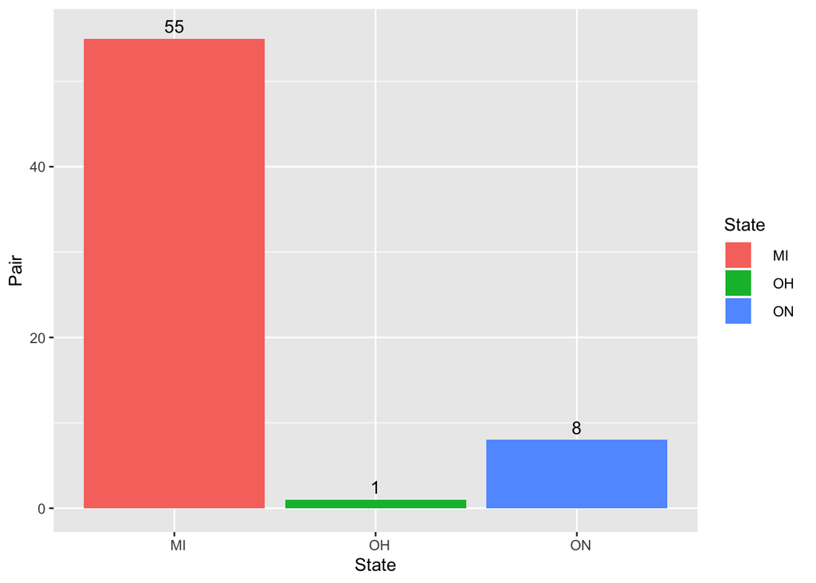

```r
ggplot(data = data_df,aes(x = State, y = `Pair`)) +
    geom_col(aes(fill = State), position = "dodge") +
    geom_text(
    aes(label = `Pair`, y = `Pair` + 0.7),
    position = position_dodge(0.9),
    vjust = 0
  )
```

##### As concluded from the graph that the majority of the players are from **MI** where 85% of players are from there.

##### Now, let’s check out if **MI** residents plays all rounds.

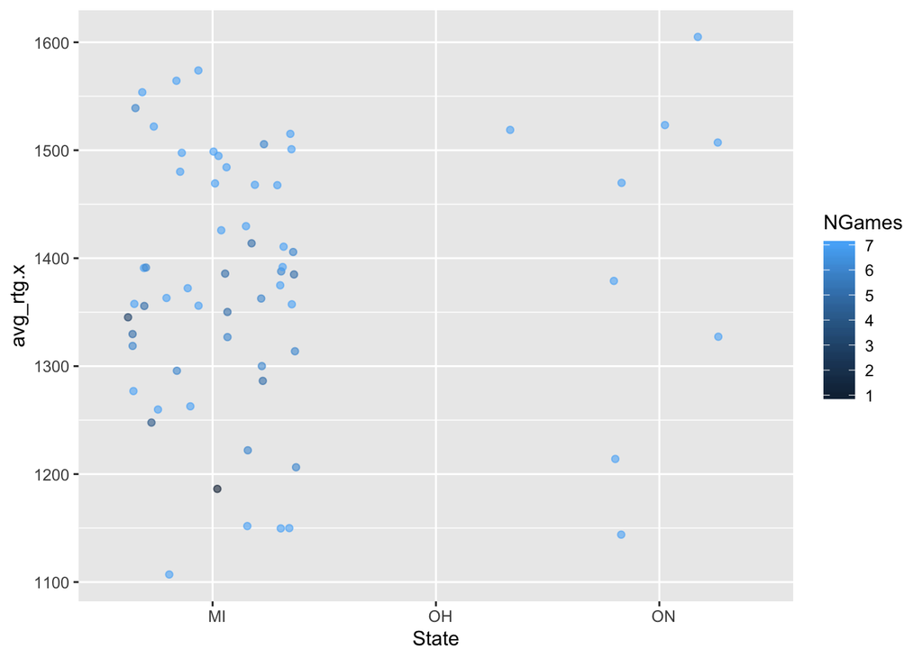

```r
chess_df %>%
filter(NGames >= 1) %>%
ggplot(aes(x = State, y = avg_rtg.x, colour = NGames)) +
geom_point(alpha = 0.6,  position = position_jitter()) + stat_smooth(method = "lm")
```

#### It shows that the majority of players in the three states played their 7 games. Get the **average pre-rating** for each **State** to find out its statistics (mean, median, max, and min)

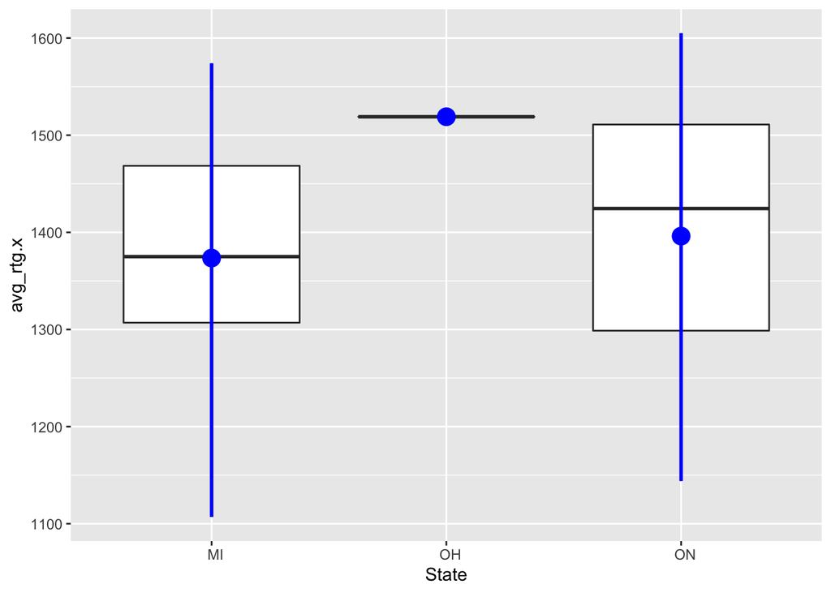

```r
ggplot(chess_df, aes(x = State, y = avg_rtg.x)) +
  geom_boxplot() +
    stat_summary(
      fun.y = mean,
      fun.ymin = min,
      fun.ymax = max,
      colour = "blue",
      size = 1
    )
```

##### As Illustrated, the mean for **ON** state is higher than **MI** state, the max is higher fir **ON** as well; however, the min is nearly the same. From observation, we can exclude **OH** from comparasion because it has only one player and the pre-rating average value is above **1500**.

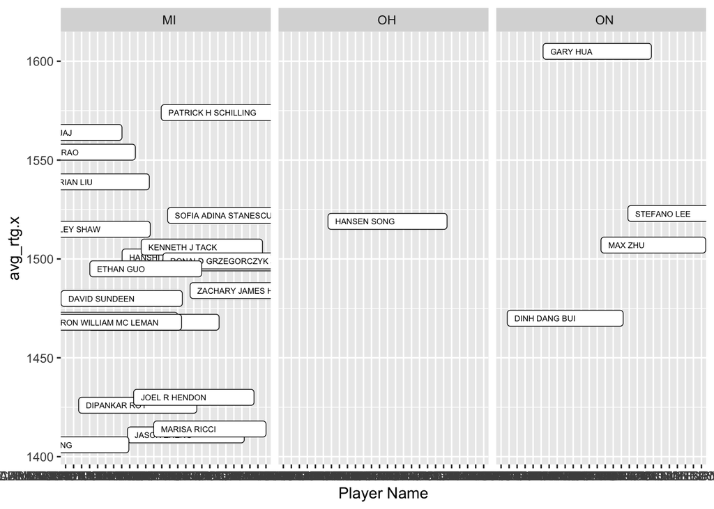

```r
chess_df %>%
filter(avg_rtg.x >= 1400) %>%
ggplot(aes(`Player Name`, avg_rtg.x)) +
  geom_label(aes(label = `Player Name`), size = 2) +
  facet_grid( ~ State )
```

## Conclusion and next steps

After getting basic exploring analysis for the chess tournament, we need further information about each player to get more details about the winning factors. For example, have more details about game time for each player, age, education,..etc.

## Adjusting the table header to exactly matches the user requirement.

In this section, I will remove the extra columns for Pair,Post, Pts and change the columns names to match the user requirements .

```r
colnames(chess_df)
```

```
##  [1] "Pair"        "Player Name" "State"       "Pre"         "Post"
##  [6] "Total"       "Pts"         "avg_rtg.x"   "avg_rtg.y"   "Opp 1"
## [11] "Opp 2"       "Opp 3"       "Opp 4"       "Opp 5"       "Opp 6"
## [16] "Opp 7"       "NGames"
```

```r
chess_tournament <- chess_df[, -c(1,5,7,9,10,11,12,13,14,15,16,17)]
chess_tournament
```

| Player Name | State | Pre | Total | avg_rtg.x |
| --- | --- | --- | --- | --- |
| GARY HUA | ON | 1794 | 6.0 | 1605 |
| DAKSHESH DARURI | MI | 1553 | 6.0 | 1469 |
| ADITYA BAJAJ | MI | 1384 | 6.0 | 1564 |
| PATRICK H SCHILLING | MI | 1716 | 5.5 | 1574 |
| HANSHI ZUO | MI | 1655 | 5.5 | 1501 |
| HANSEN SONG | OH | 1686 | 5.0 | 1519 |
| GARY DEE SWATHELL | MI | 1649 | 5.0 | 1372 |
| EZEKIEL HOUGHTON | MI | 1641 | 5.0 | 1468 |
| STEFANO LEE | ON | 1411 | 5.0 | 1523 |
| ANVIT RAO | MI | 1365 | 5.0 | 1554 |

[output cut: 54 more lines]

```r
names(chess_tournament) <- c("Player’s Name", "Player’s State", "Total Number of Points", "Player’s Pre-Rating", " Average Pre Chess Rating")
chess_tournament  %>% kable() %>% kable_styling(bootstrap_options = c("striped", "hover", "condensed", "responsive")) %>% scroll_box(width="100%",height="300px")
```

| Player’s Name | Player’s State | Total Number of Points | Player’s Pre-Rating | Average Pre Chess Rating |
| --- | --- | --- | --- | --- |
| GARY HUA | ON | 1794 | 6.0 | 1605 |
| DAKSHESH DARURI | MI | 1553 | 6.0 | 1469 |
| ADITYA BAJAJ | MI | 1384 | 6.0 | 1564 |
| PATRICK H SCHILLING | MI | 1716 | 5.5 | 1574 |
| HANSHI ZUO | MI | 1655 | 5.5 | 1501 |
| HANSEN SONG | OH | 1686 | 5.0 | 1519 |
| GARY DEE SWATHELL | MI | 1649 | 5.0 | 1372 |
| EZEKIEL HOUGHTON | MI | 1641 | 5.0 | 1468 |
| STEFANO LEE | ON | 1411 | 5.0 | 1523 |
| ANVIT RAO | MI | 1365 | 5.0 | 1554 |
| CAMERON WILLIAM MC LEMAN | MI | 1712 | 4.5 | 1468 |
| KENNETH J TACK | MI | 1663 | 4.5 | 1506 |
| TORRANCE HENRY JR | MI | 1666 | 4.5 | 1498 |
| BRADLEY SHAW | MI | 1610 | 4.5 | 1515 |
| ZACHARY JAMES HOUGHTON | MI | 1220 | 4.5 | 1484 |
| MIKE NIKITIN | MI | 1604 | 4.0 | 1386 |
| RONALD GRZEGORCZYK | MI | 1629 | 4.0 | 1499 |
| DAVID SUNDEEN | MI | 1600 | 4.0 | 1480 |
| DIPANKAR ROY | MI | 1564 | 4.0 | 1426 |
| JASON ZHENG | MI | 1595 | 4.0 | 1411 |
| DINH DANG BUI | ON | 1563 | 4.0 | 1470 |
| EUGENE L MCCLURE | MI | 1555 | 4.0 | 1300 |
| ALAN BUI | ON | 1363 | 4.0 | 1214 |
| MICHAEL R ALDRICH | MI | 1229 | 4.0 | 1357 |
| LOREN SCHWIEBERT | MI | 1745 | 3.5 | 1363 |
| MAX ZHU | ON | 1579 | 3.5 | 1507 |
| GAURAV GIDWANI | MI | 1552 | 3.5 | 1222 |
| SOFIA ADINA STANESCUBELLU | MI | 1507 | 3.5 | 1522 |
| CHIEDOZIE OKORIE | MI | 1602 | 3.5 | 1314 |
| GEORGE AVERY JONES | ON | 1522 | 3.5 | 1144 |
| RISHI SHETTY | MI | 1494 | 3.5 | 1260 |
| JOSHUA PHILIP MATHEWS | ON | 1441 | 3.5 | 1379 |
| JADE GE | MI | 1449 | 3.5 | 1277 |
| MICHAEL JEFFERY THOMAS | MI | 1399 | 3.5 | 1375 |
| JOSHUA DAVID LEE | MI | 1438 | 3.5 | 1150 |
| SIDDHARTH JHA | MI | 1355 | 3.5 | 1388 |
| AMIYATOSH PWNANANDAM | MI | 980 | 3.5 | 1385 |
| BRIAN LIU | MI | 1423 | 3.0 | 1539 |
| JOEL R HENDON | MI | 1436 | 3.0 | 1430 |
| FOREST ZHANG | MI | 1348 | 3.0 | 1391 |
| KYLE WILLIAM MURPHY | MI | 1403 | 3.0 | 1248 |
| JARED GE | MI | 1332 | 3.0 | 1150 |
| ROBERT GLEN VASEY | MI | 1283 | 3.0 | 1107 |
| JUSTIN D SCHILLING | MI | 1199 | 3.0 | 1327 |
| DEREK YAN | MI | 1242 | 3.0 | 1152 |
| JACOB ALEXANDER LAVALLEY | MI | 377 | 3.0 | 1358 |
| ERIC WRIGHT | MI | 1362 | 2.5 | 1392 |
| DANIEL KHAIN | MI | 1382 | 2.5 | 1356 |
| MICHAEL J MARTIN | MI | 1291 | 2.5 | 1286 |
| SHIVAM JHA | MI | 1056 | 2.5 | 1296 |
| TEJAS AYYAGARI | MI | 1011 | 2.5 | 1356 |
| ETHAN GUO | MI | 935 | 2.5 | 1495 |
| JOSE C YBARRA | MI | 1393 | 2.0 | 1345 |
| LARRY HODGE | MI | 1270 | 2.0 | 1206 |
| ALEX KONG | MI | 1186 | 2.0 | 1406 |
| MARISA RICCI | MI | 1153 | 2.0 | 1414 |
| MICHAEL LU | MI | 1092 | 2.0 | 1363 |
| VIRAJ MOHILE | MI | 917 | 2.0 | 1391 |
| SEAN M MC CORMICK | MI | 853 | 2.0 | 1319 |
| JULIA SHEN | MI | 967 | 1.5 | 1330 |
| JEZZEL FARKAS | ON | 955 | 1.5 | 1327 |
| ASHWIN BALAJI | MI | 1530 | 1.0 | 1186 |
| THOMAS JOSEPH HOSMER | MI | 1175 | 1.0 | 1350 |
| BEN LI | MI | 1163 | 1.0 | 1263 |

## Export to CSV file

```r
file_to_export <- write.table(chess_tournament, file = "chess_tournamentInfo.csv", row.names = FALSE, na="", col.names = TRUE, sep = ",")
```

## Test that the file is already created.

*Please be sure that you set working directory in Rstudio to the current working directory.*

```r
file_test("-f", "~/Desktop/MSDS_2019/Fall2019/aquisition&management_607/project_1/chess_tournamentInfo.csv")
```

```
## [1] TRUE
```

## open the file from local machine

```r
file_to_open <- read.csv(file = "chess_tournamentInfo.csv", header = TRUE, sep = ",")

file_to_open   %>% kable() %>% kable_styling(bootstrap_options = c("striped", "hover", "condensed", "responsive")) %>% scroll_box(width="100%",height="300px")
```

| Player.s.Name | Player.s.State | Total.Number.of.Points | Player.s.Pre.Rating | X.Average.Pre.Chess.Rating |
| --- | --- | --- | --- | --- |
| GARY HUA | ON | 1794 | 6.0 | 1605 |
| DAKSHESH DARURI | MI | 1553 | 6.0 | 1469 |
| ADITYA BAJAJ | MI | 1384 | 6.0 | 1564 |
| PATRICK H SCHILLING | MI | 1716 | 5.5 | 1574 |
| HANSHI ZUO | MI | 1655 | 5.5 | 1501 |
| HANSEN SONG | OH | 1686 | 5.0 | 1519 |
| GARY DEE SWATHELL | MI | 1649 | 5.0 | 1372 |
| EZEKIEL HOUGHTON | MI | 1641 | 5.0 | 1468 |
| STEFANO LEE | ON | 1411 | 5.0 | 1523 |
| ANVIT RAO | MI | 1365 | 5.0 | 1554 |
| CAMERON WILLIAM MC LEMAN | MI | 1712 | 4.5 | 1468 |
| KENNETH J TACK | MI | 1663 | 4.5 | 1506 |
| TORRANCE HENRY JR | MI | 1666 | 4.5 | 1498 |
| BRADLEY SHAW | MI | 1610 | 4.5 | 1515 |
| ZACHARY JAMES HOUGHTON | MI | 1220 | 4.5 | 1484 |
| MIKE NIKITIN | MI | 1604 | 4.0 | 1386 |
| RONALD GRZEGORCZYK | MI | 1629 | 4.0 | 1499 |
| DAVID SUNDEEN | MI | 1600 | 4.0 | 1480 |
| DIPANKAR ROY | MI | 1564 | 4.0 | 1426 |
| JASON ZHENG | MI | 1595 | 4.0 | 1411 |
| DINH DANG BUI | ON | 1563 | 4.0 | 1470 |
| EUGENE L MCCLURE | MI | 1555 | 4.0 | 1300 |
| ALAN BUI | ON | 1363 | 4.0 | 1214 |
| MICHAEL R ALDRICH | MI | 1229 | 4.0 | 1357 |
| LOREN SCHWIEBERT | MI | 1745 | 3.5 | 1363 |
| MAX ZHU | ON | 1579 | 3.5 | 1507 |
| GAURAV GIDWANI | MI | 1552 | 3.5 | 1222 |
| SOFIA ADINA STANESCUBELLU | MI | 1507 | 3.5 | 1522 |
| CHIEDOZIE OKORIE | MI | 1602 | 3.5 | 1314 |
| GEORGE AVERY JONES | ON | 1522 | 3.5 | 1144 |
| RISHI SHETTY | MI | 1494 | 3.5 | 1260 |
| JOSHUA PHILIP MATHEWS | ON | 1441 | 3.5 | 1379 |
| JADE GE | MI | 1449 | 3.5 | 1277 |
| MICHAEL JEFFERY THOMAS | MI | 1399 | 3.5 | 1375 |
| JOSHUA DAVID LEE | MI | 1438 | 3.5 | 1150 |
| SIDDHARTH JHA | MI | 1355 | 3.5 | 1388 |
| AMIYATOSH PWNANANDAM | MI | 980 | 3.5 | 1385 |
| BRIAN LIU | MI | 1423 | 3.0 | 1539 |
| JOEL R HENDON | MI | 1436 | 3.0 | 1430 |
| FOREST ZHANG | MI | 1348 | 3.0 | 1391 |
| KYLE WILLIAM MURPHY | MI | 1403 | 3.0 | 1248 |
| JARED GE | MI | 1332 | 3.0 | 1150 |
| ROBERT GLEN VASEY | MI | 1283 | 3.0 | 1107 |
| JUSTIN D SCHILLING | MI | 1199 | 3.0 | 1327 |
| DEREK YAN | MI | 1242 | 3.0 | 1152 |
| JACOB ALEXANDER LAVALLEY | MI | 377 | 3.0 | 1358 |
| ERIC WRIGHT | MI | 1362 | 2.5 | 1392 |
| DANIEL KHAIN | MI | 1382 | 2.5 | 1356 |
| MICHAEL J MARTIN | MI | 1291 | 2.5 | 1286 |
| SHIVAM JHA | MI | 1056 | 2.5 | 1296 |
| TEJAS AYYAGARI | MI | 1011 | 2.5 | 1356 |
| ETHAN GUO | MI | 935 | 2.5 | 1495 |
| JOSE C YBARRA | MI | 1393 | 2.0 | 1345 |
| LARRY HODGE | MI | 1270 | 2.0 | 1206 |
| ALEX KONG | MI | 1186 | 2.0 | 1406 |
| MARISA RICCI | MI | 1153 | 2.0 | 1414 |
| MICHAEL LU | MI | 1092 | 2.0 | 1363 |
| VIRAJ MOHILE | MI | 917 | 2.0 | 1391 |
| SEAN M MC CORMICK | MI | 853 | 2.0 | 1319 |
| JULIA SHEN | MI | 967 | 1.5 | 1330 |
| JEZZEL FARKAS | ON | 955 | 1.5 | 1327 |
| ASHWIN BALAJI | MI | 1530 | 1.0 | 1186 |
| THOMAS JOSEPH HOSMER | MI | 1175 | 1.0 | 1350 |
| BEN LI | MI | 1163 | 1.0 | 1263 |

## Open the file from GitHub account

```r
chess_tournament_df <-read.csv("https://raw.githubusercontent.com/salma71/MSDS_2019/master/Fall2019/aquisition%26management_607/project_1/chess_tournamentInfo.csv")

# reading the url as a dataframe
head(chess_tournament_df)  %>% kable() %>% kable_styling(bootstrap_options = c("striped", "hover", "condensed", "responsive")) %>% scroll_box(width="100%",height="300px")
```

| Player.s.Name | Player.s.State | Total.Number.of.Points | Player.s.Pre.Rating | X.Average.Pre.Chess.Rating |
| --- | --- | --- | --- | --- |
| GARY HUA | ON | 1794 | 6.0 | 1605 |
| DAKSHESH DARURI | MI | 1553 | 6.0 | 1469 |
| ADITYA BAJAJ | MI | 1384 | 6.0 | 1564 |
| PATRICK H SCHILLING | MI | 1716 | 5.5 | 1574 |
| HANSHI ZUO | MI | 1655 | 5.5 | 1501 |
| HANSEN SONG | OH | 1686 | 5.0 | 1519 |

## Important links

- Final csv file on GitHub: final csv_file
- The R Markdown file including the R script on GitHub: final_Rmd file